# 自学是门手艺

## 处理字符串的 Method

在 Python 中，字符串是一个**对象** —— 更准确地讲，是 str 类（`Class str`）的对象。

第一部分尚未读完的你，暂时不用了解对象究竟是什么；只需要知道的是，一个对象的内部有很多函数…… 这些写在对象内部的函数，有个专门的名称，类的**方法**（Method）。问题在于，在讲解编程的内容里，“方法”这个词（比如，处理数值的_方法_是……）随处可见；所以，**为了避免歧义**，以后的文字里，提到“类的方法”的时候，直接用 **Method** 这个英文单词……

字符串有很多可以调用 Methods。以下介绍的 `str` Methods，在官方文档 "[Text Sequence Type](https://docs.python.org/3/library/stdtypes.html#text-sequence-type-str)" 中都可以找到。

调用 str 类的 Methods 的方法是使用 `.` 这个符号，比如：

```
'Python'.upper()
```

### 大小写转换

转换字符串大小写的是 `str.upper()`、 `str.lower()` 和 `str.swapcase()`，以及 `str.casefold()`；另外，还有专门针对行首字母大写的 `str.capitalize()` 和针对每个词的首字母大写的 `str.title()`：

```python
from IPython.core.interactiveshell import InteractiveShell
InteractiveShell.ast_node_interactivity = "all"

'Now is better than never.'.upper()

# 在 Python 命令行工具之中，单个下划线，是个特殊变量；
# 保存着最近的语句或者表达式的结果
# 上一个 Cell 执行过后，_ 中保存着 'NOW IS BETTER THAN NEVER.'

_.lower()
```

```
'NOW IS BETTER THAN NEVER.'
```

```
'now is better than never.'
```

```python
from IPython.core.interactiveshell import InteractiveShell
InteractiveShell.ast_node_interactivity = "all"

# casefold() 也是转换成小写，但它能处理更多欧洲语言字符

'ß'.casefold()           # 德语字符中，大写 ß 的小写形式是 ss
len('ß'.casefold())
'ß'.lower()              # lower() 对这类字符无能为力……
len('ß'.lower())
# casefold
'\u0132'                # Ĳ 这个字符的 Unicode 编码
'\u0132'.casefold()
'\u0132'.lower()        # 对这个字符来说，lower() 和 casefold 的效果一样
len('\u0132'.casefold())

# 这是一篇有用的文章：
# Truths programmers should know about case
# https://www.b-list.org/weblog/2018/nov/26/case/
```

```
'ss'
```

```
2
```

```
'ß'
```

```
1
```

```
'Ĳ'
```

```
'ĳ'
```

```
'ĳ'
```

```
1
```

```python
from IPython.core.interactiveshell import InteractiveShell
InteractiveShell.ast_node_interactivity = "all"

s = 'Now is better than never.'
s.capitalize() # 句首字母大写
s.title() # 每个单词首字母大写
```

```
'Now is better than never.'
```

```
'Now Is Better Than Never.'
```

```python
s = 'Now is better than never.'
s.swapcase() # 逐个字符更替大小写
s.title()
s.title().swapcase()
```

```
'nOW IS BETTER THAN NEVER.'
```

```
'Now Is Better Than Never.'
```

```
'nOW iS bETTER tHAN nEVER.'
```

另外，还有个 `str.encode()` 在处理非英文字符串（比如中文）的时候，经常会用到：

```python
# str.encode(encoding="utf-8", errors="strict")
# 关于更多可能得 encoding list, 请参阅：
# https://docs.python.org/3/library/codecs.html#standard-encodings
s = '简单优于复杂。'
s.encode()
```

```
b'\xe7\xae\x80\xe5\x8d\x95\xe4\xbc\x98\xe4\xba\x8e\xe5\xa4\x8d\xe6\x9d\x82\xe3\x80\x82'
```

### 搜索与替换

让我们从 `str.count()` 这个搜寻子字符串出现次数的 Method（即，`str` 这个 `Class` 中定义的函数）开始。

它官方文档是这么写的：

> `str.count(sub[,start[,end]])`

下面的函数说明加了默认值，以便初次阅读更容易理解：

> `str.count(sub [,start=0[, end=len(str)-1]])`

这里的方括号 `[]` 表示该参数可选；方括号里再次嵌套了一个方括号，这个意思是说，在这个可选参数 `start` 出现的情况下，还可以再有一个可选参数 `end`；

而 `=` 表示该参数有个默认值。上述这段说明如果你感到熟悉的话，说明前面的内容确实阅读到位了……与大量“前置引用”相伴随的是知识点的重复出现。

> - 只给定 `sub` 一个参数的话，于是从第一个字符开始搜索到结束；
> - 如果，随后给定了一个可选参数的话，那么它是 `start`，于是从 `start` 开始，搜索到字符串结束；
> - 如果 `start` 之后还有参数的话，那么它是 `end`；于是从 `start` 开始，搜索到 `end` 结束。

> 返回值为在字符串中 `sub` 出现的次数。

注意：字符串中第一个字符的索引值是 `0`。

```python
from IPython.core.interactiveshell import InteractiveShell
InteractiveShell.ast_node_interactivity = "all"

s = """Simple is better than complex.
Complex is better than complicated."""
s.lower().count('mp')
s.lower().count('mp', 10)
s.lower().count('mp', 10, 30)
```

```
4
```

```
3
```

```
1
```

以下是 `str` 的搜索与替换的 Methods： `str.find()`, `str.rfind()`, `str.index()` 的示例：

```python
from IPython.core.interactiveshell import InteractiveShell
InteractiveShell.ast_node_interactivity = "all"

# str.find(sub[, start[, end]])
print('Example of str.find():')
s = """Simple is better than complex.
Complex is better than complicated."""
s.lower().find('mpl')
s.lower().find('mpl', 10)
s.lower().find('mpl', 10, 20) # 没有找到就返回 -1
print()

print('Example of str.rfind():')
# str.rfind(sub[, start[, end]])
# rfind() 返回最后 sub 出现的那次的位置；find()是最早的那次
s.lower().rfind('mpl')
s.lower().rfind('mpl', 10)
s.lower().rfind('mpl', 10, 20) # 没有找到就返回 -1
print()

print('Example of str.index():')
# str.index(sub[, start[, end]])
# 作用与 find() 相同，但，如果没找到的话，会触发 ValueError 异常
# https://docs.python.org/3/library/exceptions.html#ValueError
s.lower().index('mpl')
# str.rindex(sub[, start[, end]])
# 作用与 rfind() 相同，但，如果没找到的话，会触发 ValueError 异常
s.lower().rindex('mpl')
print()
```

```
Example of str.find():
```

```
2
```

```
24
```

```
-1
```

```
Example of str.rfind():
```

```
56
```

```
56
```

```
-1
```

```
Example of str.index():
```

```
2
```

```
56
```

`str.startswith()` 和 `str.endswith()` 是用来判断一个_字符串_是否以某个_子字符串_起始或者结束的：

```python
s = """Simple is better than complex.
Complex is better than complicated."""

# str.startswith(prefix[, start[, end]])
print("s.lower().startswith('S'):", \
      s.lower().startswith('S'))
print("s.lower().startswith('b'):", \
      s.lower().startswith('b', 10))
print("s.lower().startswith('e', 11, 20):", \
      s.lower().startswith('e', 11, 20))

# str.endswith(suffix[, start[, end]])
print("s.lower().endswith('.'):", \
      s.lower().endswith('.'))
print("s.lower().endswith('.', 10):", \
      s.lower().endswith('.', 10))
print("s.lower().endswith('.', 10, 20):", \
      s.lower().endswith('.', 10, 20))

# 好玩：中国人一不小心就会把这两个函数写成或者记成
# startwith() 和 endwith() —— 少写一个 s!
```

[output not shown]

为了找到位置而进行搜索之前，你可能经常需要事先确认需要寻找的字符串在寻找对象中是否存在，这个时候，可以用 `in` 操作符：

```python
s = """Simple is better than complex.
Complex is better than complicated."""
# 如果你只想知道“有没有”，而无需知道“在哪里”，那么可以用：
print('mpl' in s)
```

```
True
```

能搜索，就应该能替换 —— `str.replace()`，它的函数说明是这样的：

> `str.replace(old, new[, count])`

用 `new` 替换 `old`，替换 `count` 个实例，其中，`count` 这个参数是可选的。

```python
s = """Simple is better than complex.
Complex is better than complicated."""

# str.startswith(prefix[, start[, end]])
print("s.lower().replace('mp', '[ ]', 2):\n")
print(s.lower().replace('mp', '[ ]', 2))
```

```
s.lower().replace('mp', '[ ]', 2):

si[ ]le is better than co[ ]lex.
complex is better than complicated.
```

另外，还有个专门替换 TAB（`\t`）的 Method，

> `str.expandtabs( tabsize=8)`

它的作用非常简单，就是把字符串中的 TAB（`\t`）替换成空格，默认是替换成 `8` 个空格 —— 当然你也可以指定究竟替换成几个空格

```python
from IPython.core.interactiveshell import InteractiveShell
InteractiveShell.ast_node_interactivity = "all"

# str.expandtabs(tabsize=8)
s = "Special\tcases\taren't\tspecial\tenough\tto\tbreak\tthe\trules."
s.expandtabs()
s.expandtabs(2)
```

```
"Special cases   aren't  special enough  to      break   the     rules."
```

```
"Special cases aren't  special enough  to  break the rules."
```

### 去除子字符

> `str.strip([chars])`

它最常用的场景是去除一个字符串首尾的所有空白，包括空格、TAB、换行符等等。

```python
from IPython.core.interactiveshell import InteractiveShell
InteractiveShell.ast_node_interactivity = "all"

s = "\r \t Simple is better than complex.    \t \n"
s
s.strip()
```

```
'\r \t Simple is better than complex.    \t \n'
```

```
'Simple is better than complex.'
```

但是，如果给定了一个字符串作为参数，那么参数字符串中的所有字母都会被当做需要从首尾剔除的对象：

```python
from IPython.core.interactiveshell import InteractiveShell
InteractiveShell.ast_node_interactivity = "all"

s = "Simple is better than complex."
s
s.strip('Six.p')    # p 全部处理完之后，p 并不在首尾，所以原字符串中的 p 字母不受影响；
s.strip('pSix.mle') # 这一次，首尾的 p 被处理了…… 参数中的字符顺序对结果没有影响，换成 Sipx.mle 也一样……
```

```
'Simple is better than complex.'
```

```
'mple is better than comple'
```

```
' is better than co'
```

还可以只对左侧处理，`str.lstrip()` 或者只对右侧处理，`str.rstrip()`

```python
from IPython.core.interactiveshell import InteractiveShell
InteractiveShell.ast_node_interactivity = "all"

# str.lstrip([chars])
s = "Simple is better than complex."
s
s.lstrip('Six.p')    # p 全部处理完之后，p 并不在首部，所以原字符串中的 p 字母不受影响；
s.lstrip('pSix.mle') # 这一次，首部的 p 被处理了…… 参数中的字符顺序对结果没有影响，换乘 Sipx.mle 也一样……
```

```
'Simple is better than complex.'
```

```
'mple is better than complex.'
```

```
' is better than complex.'
```

```python
from IPython.core.interactiveshell import InteractiveShell
InteractiveShell.ast_node_interactivity = "all"

# str.rstrip([chars])
s = "Simple is better than complex."
s
s.rstrip('Six.p')    # p 全部处理完之后，p 并不在尾部，所以原字符串中的 p 字母不受影响；
s.rstrip('pSix.mle') # 这一次，尾部的 p 被处理了…… 参数中的字符顺序对结果没有影响，换乘 Sipx.mle 也一样……
```

```
'Simple is better than complex.'
```

```
'Simple is better than comple'
```

```
'Simple is better than co'
```

### 拆分字符串

在计算机里，数据一般保存在文件之中。计算机擅长处理的是“格式化数据”，即，这些数据按照一定的格式排列 —— 电子表格、数据库，就是一种保存方式。Microsoft 的 Excel 和 Apple 的 Numbers，都可以将表格导出为 `.cvs` 文件。这是文本文件，里面的每一行可能由多个数据构成，数据之间用 `,`（或 `;`、 `\t`）分隔：

```
Name,Age,Location
John,18,New York
Mike,22,San Francisco
Janny,25,Miami
Sunny,21,Shanghai
```

文本文件中的这样一段内容，被读进来之后，保存在某个变量，那么，那个变量的值长成这个样子：

> `'Name,Age,Location\nJohn,18,New York\nMike,22,San Francisco\nJanny,25,Miami\nSunny,21,Shanghai'`

我们可以对这样的字符串进行很多操作，最常用的比如，`str.splitlines()`, `str.split()`；还有个 `str.partition()`，有空的人可以去[官方文档](https://docs.python.org/3/library/stdtypes.html#str.partition)看看说明。

`str.splitlines()` 返回的是个列表（List）—— 这又是一个前面曾简要提起过，但会在后面的章节才能详细讲解的概念 —— 由被拆分的每一行作为其中的元素。

```python
from IPython.core.interactiveshell import InteractiveShell
InteractiveShell.ast_node_interactivity = "all"

s = """Name,Age,Location
John,18,New York
Mike,22,San Francisco
Janny,25,Miami
Sunny,21,Shanghai"""

s                 # s 被打印出来的时候，\n 都被转换成换行了
s.splitlines()    # 注意输出结果前后的方括号，[]，表示这个返回结果是一个 List
```

```
'Name,Age,Location\nJohn,18,New York\nMike,22,San Francisco\nJanny,25,Miami\nSunny,21,Shanghai'
```

```
['Name,Age,Location',
 'John,18,New York',
 'Mike,22,San Francisco',
 'Janny,25,Miami',
 'Sunny,21,Shanghai']
```

`str.split()`, 是将一个字符串，根据分隔符进行拆分：

> `str.split(sep=None, maxsplit=-1)`

```python
from IPython.core.interactiveshell import InteractiveShell
InteractiveShell.ast_node_interactivity = "all"

s = """Name,Age,Location
John,18,New York
Mike,22,San Francisco
Janny,25,Miami
Sunny,21,Shanghai"""

r = s.splitlines()[2]   # 取出返回列表中索引值为 2 的那一行
r
r.split()               # 如果没有给 str.split() 传递参数，那么默认为用 None 分割（各种空白，比如，\t 和 \r 都被当作 None）
r.split(sep=',')
r.split(',')            # 上一行可以这样写。

r.split(sep=',', maxsplit=1)  # 第二个参数指定拆分几次
# r.split(sep=',', 1)         # 上一行不能这样写。
r.split(sep=',', maxsplit=0)  # 0 次，即不拆分
r.split(sep=',', maxsplit=-1) # 默认值是 -1，拆分全部
```

```
'Mike,22,San Francisco'
```

```
['Mike,22,San', 'Francisco']
```

```
['Mike', '22', 'San Francisco']
```

```
['Mike', '22', 'San Francisco']
```

```
['Mike', '22,San Francisco']
```

```
['Mike,22,San Francisco']
```

```
['Mike', '22', 'San Francisco']
```

### 拼接字符串

`str.join()` 是将来非常常用的，它的官方文档说明却很少：

> `str.join(_iterable_)`

> Return a string which is the concatenation of the strings in iterable. A *[`TypeError`](https://docs.python.org/3/library/exceptions.html#TypeError)* will be raised if there are any non-string values in iterable, including [`bytes`](https://docs.python.org/3/library/stdtypes.html#bytes) objects. The separator between elements is the string providing this method.

它接收的参数是 iterable，虽然你还没办法知道 iterable 究竟是什么，但这个 Method 的例子貌似可以看懂（可能你会产生“那个方括号究竟是干什么的”的疑问，也可能对前面章节提到的列表还有印象）：

```python
s = ''
t = ['P', 'y', 't', 'h', 'o', 'n']
s.join(t)
```

```
'Python'
```

### 字符串排版

将字符串居中放置 —— 前提是设定整行的长度：

> `str.center(width[, fillchar])`

注意，第 2 个参数可选，且只接收单个字符 —— `char` 是 *character* 的缩写。

```python
from IPython.core.interactiveshell import InteractiveShell
InteractiveShell.ast_node_interactivity = "all"

s = 'Sparse is better than dense!'
s.title().center(60)
s.title().center(60, '=')
s.title().center(10) # 如果宽度参数小于字符串长度，则返回原字符串


s = 'Sparse is better than dense!'
s.title().rjust(60)
s.title().rjust(60, '.')
```

```
'                Sparse Is Better Than Dense!                '
```

```
'================Sparse Is Better Than Dense!================'
```

```
'Sparse Is Better Than Dense!'
```

```
'                                Sparse Is Better Than Dense!'
```

```
'................................Sparse Is Better Than Dense!'
```

将字符串靠左或者靠右对齐放置：

> - `str.ljust(width)`
> - `str.rjust(width)`

另外，还有个字符串 Method 是，将字符串转换成左侧由 `0` 填充的指定长度字符串。例如，这在批量生成文件名的时候就很有用……

```python
for i in range(1, 11):
    filename = str(i).zfill(3) + '.mp3'
    print(filename)
```

```
001.mp3
002.mp3
003.mp3
004.mp3
005.mp3
006.mp3
007.mp3
008.mp3
009.mp3
010.mp3
```

### 格式化字符串

所谓对字符串进行格式化，指的是将特定变量插入字符串特定位置的过程。常用的 Methods 有两个，一个是 `str.format()`，另外一个是 `f-string`。

#### 使用 str.format()

这个 Method 的[官方文档说明](https://docs.python.org/3/library/stdtypes.html#str.format)，你现在是死活看不懂的：

> `str.format(*args, **kwargs)`

参数前面多了个 `*`…… 没办法，现在讲不清楚，讲了也听不明白…… 先跳过，以下只关注怎么用这个 Method。

它的作用是：

> - 在一个字符串中，插入一个或者多个占位符 —— 用大括号 `{}` 括起来；
> - 而后将 `str.format()` 相应的参数，依次插入占位符中；

占位符中可以使用由零开始的索引。

```python
from IPython.core.interactiveshell import InteractiveShell
InteractiveShell.ast_node_interactivity = "all"

name = 'John'
age = 25
'{} is {} years old.'.format(name, age)
# 不写占位符索引就默认每个占位符的索引从第一个开始是 0, 1, 2 ... (占位符数量 - 1)
# '{} {}'.format(a, b) 和 '{0} {1}'.format(a, b) 是一样的。

# '{0} is {2} years old.'.format(name, age)
# 这一句会报错，因为 2 超出实际参数索引极限

# 两个连续使用的大括号，不被认为是占位符；且只打印出一对大括号
"Are you {0}? :-{{+}}".format(name)

# "%s is %d years old." % (name, age)
# 上一行这是兼容 Python 2 的老式写法，可以从此忽略……

# str.fomrat() 里可以直接写表达式……
'{} is a grown up? {}'.format(name, age >= 18)
```

```
'John is 25 years old.'
```

```
'Are you John? :-{+}'
```

```
'John is a grown up? True'
```

#### 使用 f-string

*f-string* 与 `str.format()` 的功用差不多，只是写法简洁一些 —— 在字符串标示之前加上一个字母 `f`：

```python
from IPython.core.interactiveshell import InteractiveShell
InteractiveShell.ast_node_interactivity = "all"

# https://docs.python.org/3/library/stdtypes.html#printf-style-bytes-formatting
# f-string

name = 'John'
age = 25
f'{name} is {age} years old.'
f'{name} is a grown up? {age >= 18}'
```

```
'John is 25 years old.'
```

```
'John is a grown up? True'
```

只不过，str.format() 的用法中，索引顺序可以任意指定，于是相对更为灵活，下面的例子只是为了演示参数位置可以任意指定：

```python
name = 'John'
age = 25
'{1} is {0} years old.'.format(name, age)
```

```
'25 is John years old.'
```

### 字符串属性

字符串还有一系列的 Methods，返回的是布尔值，用来判断字符串的构成属性：

```python
# str.isalnum()
print("'1234567890'.isalnum():", \
      '1234567890'.isalnum()) # '3.14'.isalnum() 返回的是 False

# str.isalpha()
print("'abcdefghij'.isalpha():", \
      'abcdefghij'.isalpha())

# str.isascii()
print("'山巅一寺一壶酒'.isascii():", \
      '山巅一寺一壶酒'.isascii())

# str.isdecimal()
print("'0.123456789'.isdecimal():", \
      '0.1234567890'.isdecimal())

# str.isdigit()
print("'0.123456789'.isdigit():", \
      '0.1234567890'.isdigit())       #  注意，如果字符串是 identifier，返回值也是 True

# str.isnumeric()
print("'0.123456789'.isnumeric():", \
      '0.1234567890'.isnumeric())

# str.islower()
print("'Continue'.islower():", \
      'Continue'.islower())

# str.isupper()
print("'Simple Is Better Than Complex'.isupper():", \
      'Simple Is Better Than Complex'.isupper())

# str.istitle()
print("'Simple Is Better Than Complex'.istitle():", \
      'Simple Is Better Than Complex'.istitle())

# str.isprintable()
print("'\t'.isprintable():", \
      '\t'.isprintable())

# str.isspace()
print("'\t'.isspace():", \
      '\t'.isspace())

# str.isidentifier()
print("'for'.isidentifier():", \
      'for'.isidentifier())
```

[output not shown]

## 总结

这一章节显得相当繁杂。然而，这一章和下一章（关于容器），都是“用来锻炼自己耐心的好材料”……

不过，若是自己动手整理成一个表格，总结归纳一下这一章节的内容，你就会发现其实没多繁杂，总之就还是那点事儿，怎么处理字符串？用操作符、用内建函数，用 Methods。只不过，字符串的操作符和数值的操作符不一样 —— 类型不一样，操作符就当然不一样了么！—— 最不一样的地方是，字符串是有序容器的一种，所以，它有索引，所以可以根据索引提取…… 至于剩下的么，就是很常规的了，用函数处理，用 Methods 处理，只不过，Methods 相对多了一点而已。

整理成表格之后，就会发现想要全部记住其实并没多难……

> - 为了表格在一屏中可以正确显示，本来应该规规矩矩写 `str.xxx`，但，写成了 `s.xxx`……
> - 另外，操作那一行，为了分类记忆方便，把 `len()` 和 `s.join()` 也放进去了……

[figure not shown]

“记住”的方法并不是马上就只盯着表格看…… 正确方法是反复阅读这一章内容中的代码，并逐一运行，查看输出结果；还要顺手改改看看，多多体会。多次之后，再看着表格回忆知识点，直到牢记为止。

## 为什么数值没有像字符串值这样详细论述？

上一章中，我们概括地讲了各种类型的值的运算。而后并没有继续深入讲解数字的运算，而是直接“跳”到了这一章关于字符串的内容。其实，只要一张表格和一个列表就足够了（因为之前零零散散都讲过）：

Python 针对数字常用的操作符和内建函数，按照**优先级**从低到高排列：

| 名称 | 操作 | 结果 | 官方文档链接 |
| --- | --- | --- | --- |
| 加 | `1 + 2` | 3 |  |
| 减 | `2 - 1` | 1 |  |
| 乘 | `3 * 5` | 15 |  |
| 除 | `6 / 2` | 3.0 |  |
| 商 | `7 // 3` | 2 |  |
| 余 | `7 % 3` | 1 |  |
| 负 | `-6` | -6 |  |
| 正 | `+6` | 6 |  |
| 绝对值 | `abs(-1)` | 1 | [`abs()`](https://docs.python.org/3/library/functions.html#abs) |
| 转换为整数 | `int(3.14)` | 3 | [`int()`](https://docs.python.org/3/library/functions.html#int) |
| 转换为浮点数 | `float(3)` | 3.0 | [`float()`](https://docs.python.org/3/library/functions.html#float) |
| 商余 | `divmod(7, 3)` | 2, 1 | [`divmod()`](https://docs.python.org/3/library/functions.html#divmod) |
| 幂 | `pow(2, 10)` | 1024 | [`pow()`](https://docs.python.org/3/library/functions.html#pow) |
| 幂 | `3 ** 2` | 9 |  |

Python 用来处理数值的内建函数：

> - `abs(n)` 函数返回参数 `n` 的*绝对值*；
> - `int(n)` 用来将*浮点数字* `n` 换成*整数*；
> - `float(n)` 用来将*整数* `n` 转换成*浮点数字*；
> - `divmod(n, m)` 用来计算 `n` 除以 `m`， 返回两个整数，一个是*商*，另外一个是*余*；
> - `pow(n, m)` 用来做乘方运算，返回 `n` 的 `m` *次方*；
> - `round(n)` 返回离浮点数字 `n` 最近的那个*整数*。

Python 做更为复杂的数学计算的模块（Module）是 math module，参阅：

> https://docs.python.org/3/library/math.html

**脚注**

[1]：请查阅 https://en.wikipedia.org/wiki/Unicode

↑Back to Content↑

# 数据容器

在 Python 中，有个**数据容器**（Container） 的概念。

其中包括**字符串**、由 `range()` 函数生成的**等差数列**、**列表**（List）、**元组**（Tuple）、**集合**（Set）、**字典**（Dictionary）。

这些容器，各有各的用处。其中又分为_可变_容器（Mutable） 和_不可变_容器（Immutable）。可变的有列表、集合、字典；不可变的有字符串、`range()` 生成的等差数列、元组。集合，又分为 *Set* 和 *Frozen Set*；其中，Set 是*可变的*，Frozen Set 是*不可变的*。

字符串、由 `range()` 函数生成的等差数列、列表、元组是**有序类型**（Sequence Type），而集合与字典是_无序_的。

[figure not shown]

另外，集合没有_重合_元素。

## 迭代（Iterate）

数据容器里的元素是可以被**迭代的**（Iterable），它们其中包含的元素，可以被逐个访问，以便被处理。

对于数据容器，有一个操作符，`in`，用来判断某个元素是否属于某个容器。

由于数据容器的可迭代性，再加上这个操作符 `in`，在 Python 语言里写循环格外容易且方便（以字符串这个字符的容器作为例子）：

```python
for c in 'Python':
  print(c)
```

```
P
y
t
h
o
n
```

在 Python 出现之前，想要完成这样一个访问字符串中的每一个字符的循环，大抵上应该是这样的（比如 C 语言）：

```
# Written in C
char *string;

scanf("%s",string);
int i=strlen(string);
int k = 0;
while(k<i){
      printf("%c", string[k]);
      k++;
  }
```

在 Python 中，简单的 for 循环，只需要指定一个次数就可以了，因为有 range() 这个函数：

```python
for i in range(10):
  print(i)
```

```
0
1
2
3
4
5
6
7
8
9
```

即便是用比 C 更为“现代”一点的 JavaScript，也大抵上应该是这样的：

```
var i;
for (i = 0; i < 10; i++) {
  console.log（i）
}
```

当然，有时候我们也需要比较复杂的计数器，不过，Python 也不只有 `for` 循环，还有 `while` 循环，在必要的时候可以写复杂的计数器。

## 列表（List）

列表和字符串一样，是个*有序类型*（Sequence Type）的容器，其中包含着有索引编号的元素。

列表中的元素可以是不同类型。不过，在解决现实问题的时候，我们总是倾向于创建由同一个类型的数据构成的列表。遇到由不同类型数据构成的列表，我们更可能做的是想办法把不同类型的数据分门别类地拆分出来，整理清楚 —— 这种工作甚至有个专门的名称与之关联：*数据清洗*。

### 列表的生成

生成一个列表，有以下几种方法：

```
a_list = []
b_list = [1, 2, 3]
list(), or list(literable)            # 这是 Type Casting
(expression with x) for x in iterable
```

```python
a_list = []
a_list.append(1)
a_list.append(2)
print(a_list, f'has a length of {len(a_list)}.')

#range() 返回的不是 list，需要用 list() 转换，否则也没办法调用 .append()
b_list = list(range(1, 9))
b_list.append(11)
print(b_list, f'has a length of {len(b_list)}.')


c_list = [2**x for x in range(8)]
print(c_list, f'has a length of {len(c_list)}.')
```

```
[1, 2] has a length of 2.
[1, 2, 3, 4, 5, 6, 7, 8, 11] has a length of 9.
[1, 2, 4, 8, 16, 32, 64, 128] has a length of 8.
```

这最后一种方法颇为神奇：

```
[2**x for x in range(8)]
```

这种做法，叫做 **[List Comprehension](https://docs.python.org/3.7/tutorial/datastructures.html#tut-listcomps)**。

*Comprehend* 这个词的意思除了“理解”之外，还有另外一个意思，就是“包括、囊括” —— 这样的话，你就大概能理解这种做法为什么被称作 *List Comprehension* 了。中文翻译中，怎么翻译的都有，“列表生成器”、“列表生成式”等等，都挺好。但是，被翻译成“列表解析器”，就不太好了，给人的感觉是操作反了……

List comprehension 可以嵌套使用 `for`，甚至可以加上条件 `if`。官方文档里有个例子，是用来把两个元素并不完全相同的两个列表去同后拼成一个列表（下面稍作了改写）：

```python
import random

n = 10

# 生成一个 n 个元素的序列，每个元素是 1~100 之间的随机数
a_list = [random.randrange(1, 100) for i in range(n)]
print(f'a_list comprehends {len(a_list)} random numbers: {a_list}')

# 从 a_list 里把偶数都挑出来
b_list = [x for x in a_list if x % 2 == 0]
print(f'... and it has {len(b_list)} even numbers: {b_list}')
```

```
a_list comprehends 10 random numbers: [98, 93, 84, 66, 58, 66, 9, 75, 11, 21]
... and it has 5 even numbers: [98, 84, 66, 58, 66]
```

### 列表的操作符

列表的操作符和字符串一样，因为它们都是有序容器。列表的操作符有：

> - 拼接：`+` （与字符串不一样的地方是，不能用空格了 `' '`；
> - 复制：`*`
> - 逻辑运算：`in` 和 `not in`，`<`、`<=`、`>`、`>=`、`!=`、`==`

而后两个列表也和两个字符串一样，可以被比较，即，可以进行逻辑运算；比较方法也跟字符串一样，从两个列表各自的第一个元素开始逐个比较，“一旦决出胜负马上停止”：

```python
from IPython.core.interactiveshell import InteractiveShell
InteractiveShell.ast_node_interactivity = "all"

a_list = [1, 2, 3]
b_list = [4, 5, 6]
c_list = a_list + b_list * 3
c_list
7 not in c_list
a_list > b_list
```

```
[1, 2, 3, 4, 5, 6, 4, 5, 6, 4, 5, 6]
True
False
```

### 根据索引提取列表元素

列表当然也可以根据索引操作，但，由于列表是可变序列，所以，不仅可以提取，还可以删除，甚至替换。

```python
import random
n = 3
a_list = [random.randrange(65, 91) for i in range(n)]
b_list = [chr(random.randrange(65, 91)) for i in range(n)]
print(a_list)
c_list = a_list + b_list + a_list * 2
print(c_list)

print()
# 根据索引提取（Slicing）
print(c_list[3])        # 返回索引值为 3 的元素值
print(c_list[:])        # 相当于 c_list，返回整个列表
print(c_list[5:])       # 从索引为 5 的值开始直到末尾
print(c_list[:3])       # 从索引 0 开始，直到索引 3 之前（不包括 3）
print(c_list[2:6])      # 从索引 2 开始，直到索引 6 之前（不包括 6）

print()
# 根据索引删除
del c_list[3]
print(c_list)           # del 是个命令，del c_list[3] 是一个语句；不能这么写： print(del c_list[3])
del c_list[5:8]
print(c_list)

print()
# 根据索引替换
c_list[1:5:2] = ['a', 2]  # s[start:stop:step] = t，跟 range 的三个参数类似；
                         # len(t) = len([start:stop:step]) 必须为真
print(c_list)
```

```
[77, 80, 86]
[77, 80, 86, 'E', 'U', 'J', 77, 80, 86, 77, 80, 86]

E
[77, 80, 86, 'E', 'U', 'J', 77, 80, 86, 77, 80, 86]
['J', 77, 80, 86, 77, 80, 86]
[77, 80, 86]
[86, 'E', 'U', 'J']

[77, 80, 86, 'U', 'J', 77, 80, 86, 77, 80, 86]
[77, 80, 86, 'U', 'J', 77, 80, 86]

[77, 'a', 86, 2, 'J', 77, 80, 86]
```

需要注意的地方是：**列表**（List）是可变序列，而**字符串**（str）是不可变序列，所以，对字符串来说，虽然也可以根据索引提取，但没办法根据索引删除或者替换。

```python
s = 'Python'[2:5]
print(s)
del s[3]  # 这一句会报错
```

```
tho
```

```
---------------------------------------------------------------------------
TypeError                                 Traceback (most recent call last)
<ipython-input-4-c9c999709965> in <module>
      1 s = 'Python'[2:5]
      2 print(s)
----> 3 del s[3]  # 这一句会报错

TypeError: 'str' object doesn't support item deletion
```

之前提到过：

> 字符串常量（String Literal）是不可变有序容器，所以，虽然字符串也有一些 Methods 可用，但，那些 Methods 都不改变它们自身，而是在操作后返回一个值给另外一个变量。

而对于列表这种*可变容器*，我们可以对它进行操作，结果是*它本身被改变*了。

```python
s = 'Python'
L = list(s)
print(s)
print(L)
del L[2]
print(L) # 用 del 对 L 操作之后，L 本身少了 1 个元素
```

```
Python
['P', 'y', 't', 'h', 'o', 'n']
['P', 'y', 'h', 'o', 'n']
```

### 列表可用的内建函数

列表和字符串都是容器，它们可使用的内建函数也其实都是一样的：

> - `len()`
> - `max()`
> - `min()`

```python
import random
n = 3

# 生成 3 个随机数，构成一个列表"
a_list = [random.randrange(65, 91) for i in range(n)]
b_list = [chr(random.randrange(65, 91)) for i in range(n)]
print(a_list)
print(b_list)

# 列表可以使用操作符 + 和 *
c_list = a_list + b_list + a_list * 2
print(c_list)

a_list *= 3
print(a_list)

# 内建函数操作 len()、max()、min()
print(len(c_list))
print(max(b_list)) # 内建函数内部做了异常处理，可以比较字符和数字 —— 初学者最讨厌这种事情了……
print(min(b_list))

print('X' not in b_list)
```

```
[66, 70, 72]
['Q', 'W', 'G']
[66, 70, 72, 'Q', 'W', 'G', 66, 70, 72, 66, 70, 72]
[66, 70, 72, 66, 70, 72, 66, 70, 72]
12
W
G
True
```

### Methods

字符串常量和 range() 都是不可变的（Imutable）；而列表则是**可变类型**（Mutable type），所以，它最起码可以被排序 —— 使用 `sort()` Method：

```python
import random
n = 10
a_list = [random.randrange(1, 100) for i in range(n)]
print(f'a_list comprehends {len(a_list)} random numbers:\n', a_list)

a_list.sort()
print('the list sorted:\n', a_list)

a_list.sort(reverse=True) #reverse 参数，默认是 False
print('the list sorted reversely:\n', a_list)
```

```
a_list comprehends 10 random numbers:
 [78, 49, 36, 68, 99, 99, 47, 56, 73, 21]
the list sorted:
 [21, 36, 47, 49, 56, 68, 73, 78, 99, 99]
the list sorted reversely:
 [99, 99, 78, 73, 68, 56, 49, 47, 36, 21]
```

如果列表中的元素全都是由字符串构成的，当然也可以排序：

```python
import random
n = 10

a_list = [chr(random.randrange(65, 91)) for i in range(n)]
# chr() 函数会返回指定 ascii 码的字符，ord('A') 是 65
print(f'a_list comprehends {len(a_list)} random string elements:\n', a_list)

a_list.sort()
print('the list sorted:\n', a_list)

a_list.sort(reverse=True) #reverse 参数，默认是 False
print('the list sorted reversely:\n', a_list)

print()

b_list = [chr(random.randrange(65, 91)) +\
            chr(random.randrange(97, 123))\
            for i in range(n)]
# 可以在行末加上 \ 符号，表示“该行未完待续……”

print(f'b_list comprehends {len(b_list)} random string elements:\n', b_list)

b_list.sort()
print('the sorted:\n', b_list)

b_list.sort(key=str.lower, reverse=True)
# key 参数，默认是 None
# key=str.lower 的意思是，在比较的时候，先全都转换成小写再比较……
# —— 但并不改变原有值
print('the sorted reversely:\n', b_list)
```

```
a_list comprehends 10 random string elements:
 ['O', 'W', 'Z', 'I', 'R', 'H', 'G', 'L', 'W', 'L']
the list sorted:
 ['G', 'H', 'I', 'L', 'L', 'O', 'R', 'W', 'W', 'Z']
the list sorted reversely:
 ['Z', 'W', 'W', 'R', 'O', 'L', 'L', 'I', 'H', 'G']

b_list comprehends 10 random string elements:
 ['Ax', 'Uh', 'Gg', 'Co', 'Zh', 'Wi', 'Di', 'Is', 'Hu', 'Br']
the sorted:
 ['Ax', 'Br', 'Co', 'Di', 'Gg', 'Hu', 'Is', 'Uh', 'Wi', 'Zh']
the sorted reversely:
 ['Zh', 'Wi', 'Uh', 'Is', 'Hu', 'Gg', 'Di', 'Co', 'Br', 'Ax']
```

**注意**：不能乱比较…… 被比较的元素应该是同一类型 —— 所以，不是由同一种数据类型元素构成的列表，不能使用 `sort()` Method。下面的代码会报错：

```python
a_list = [1, 'a', 'c']
a_list = a_list.sort() # 这一句会报错
```

```
---------------------------------------------------------------------------
TypeError                                 Traceback (most recent call last)
<ipython-input-12-acb9480a455d> in <module>
      1 a_list = [1, 'a', 'c']
----> 2 a_list = a_list.sort() # 这一句会报错

TypeError: '<' not supported between instances of 'str' and 'int'
```

**可变序列**还有一系列可用的 **Methods**：`a.append()`，`a.clear()`，`a.copy()`，`a.extend(t)`，`a.insert(i， x)`，`a.pop([i])`， `a.remove(x)`， `a.reverse()`……

```python
import random
n = 3
a_list = [random.randrange(65, 91) for i in range(n)]
b_list = [chr(random.randrange(65, 91)) for i in range(n)]
print(a_list)
c_list = a_list + b_list + a_list * 2
print(c_list)

# 在末尾追加一个元素
c_list.append('100')
print(c_list)

# 清空序列
print()
print(a_list)
a_list.clear()
print(a_list)

print()
# 拷贝一个列表
d_list = c_list.copy()
print(d_list)
del d_list[6:8]
print(d_list)
print(c_list)             # 对一个拷贝操作，不会更改“原件”

print()
# 演示拷贝 .copy() 与赋值 = 的不同
e_list = d_list
del e_list[6:8]
print(e_list)
print(d_list)             # 对 e_list 操作，相等于对 d_list 操作

# 在末尾追加一个列表
print()
print(a_list)
a_list.extend(c_list)      # 相当于 a_list += c_list
print(a_list)

# 在某索引位置插入一个元素
print()
print(a_list)
a_list.insert(1, 'example')   # 在索引 1 的位置插入 'example'
a_list.insert(3, 'example')   # 在索引 3 的位置插入 'example'；
print(a_list)

# 排序

# a_list.sort() 这一句会出错，因为当前列表中的元素，是 int 和 str 混合的。

print()
print(a_list)
a_list.reverse()
print(a_list)
x = a_list.reverse() # reverse() 只对当前序列操作，并不返回一个逆序列表；返回值是 None
print(x)
```

```
[88, 83, 78]
[88, 83, 78, 'A', 'C', 'L', 88, 83, 78, 88, 83, 78]
[88, 83, 78, 'A', 'C', 'L', 88, 83, 78, 88, 83, 78, '100']

[88, 83, 78]
[]

[88, 83, 78, 'A', 'C', 'L', 88, 83, 78, 88, 83, 78, '100']
[88, 83, 78, 'A', 'C', 'L', 78, 88, 83, 78, '100']
[88, 83, 78, 'A', 'C', 'L', 88, 83, 78, 88, 83, 78, '100']

[88, 83, 78, 'A', 'C', 'L', 83, 78, '100']
[88, 83, 78, 'A', 'C', 'L', 83, 78, '100']

[]
[88, 83, 78, 'A', 'C', 'L', 88, 83, 78, 88, 83, 78, '100']

[88, 83, 78, 'A', 'C', 'L', 88, 83, 78, 88, 83, 78, '100']
[88, 'example', 83, 'example', 78, 'A', 'C', 'L', 88, 83, 78, 88, 83, 78, '100']

[88, 'example', 83, 'example', 78, 'A', 'C', 'L', 88, 83, 78, 88, 83, 78, '100']
['100', 78, 83, 88, 78, 83, 88, 'L', 'C', 'A', 78, 'example', 83, 'example', 88]
None
```

有一个命令、两个 Methods 与删除单个元素相关联， `del`，`a.pop[i]`，`a.remove(x)` ，请注意它们之间的区别。

```python
import random
n = 3
a_list = [random.randrange(65, 91) for i in range(n)]
print(a_list)

# 插入
print()
a_list.insert(1, 'example')   # 在索引 1 的位置插入 'example'

# 删除
print()
print(a_list)
a_list.remove('example')      # 去除 'example' 这个元素，如果有多个 'example'，只删除第一个
print(a_list)

# pop() 删除并返回被删除的值

print()
print(a_list)
p = a_list.pop(2)      # 去除索引为 2 的元素，且返回元素的值，赋值给 p
print(a_list)
print(p)

# pop() 与 del，或者 remove() 的区别
print()
a_list.insert(2, 'example')
a_list.insert(2, 'example')
print(a_list)
del a_list[2]
print(a_list)

print()
print(a_list.remove('example')) # a_list.remove() 这个方法的返回值是 None
print(a_list)
```

```
[86, 69, 81]


[86, 'example', 69, 81]
[86, 69, 81]

[86, 69, 81]
[86, 69]
81

[86, 69, 'example', 'example']
[86, 69, 'example']

None
[86, 69]
```

### 小结

看起来是个新概念，例子全部读完也很是要花上一段时间，然而，从操作上来看，操作列表和操作字符串的差异并不大，重点在于一个是 Immutable，另外一个是 Mutable，所以，例如像 `a.sort()`，`a.remove()` 这样的事儿，列表能做，字符串不能做 —— 字符串也可以排序，但，那是排序之后返回给另外一个变量；而列表可以直接改变自身……

而整理成表格之后呢，理解与记忆真的是零压力：

[figure not shown]

## 元组（Tuple）

在完整掌握列表的创建与操作之后，再理解元组（Tuple） 就容易了，因为它们之间的主要区别只有两个：

> - List 是*可变*有序容器，Tuple 是*不可变*有序容器。
> - List 用*方括号*标识 `[]`，Tuple 用*圆括号* 标识`()`。

创建一个元组的时候，用圆括号：

```
a = ()
```

这样就创建了一个空元组。

多个元素之间，用 `,` 分离。

创建一个含多个元素的元组，可以省略这个括号。

```python
a = 1, 2, 3   # 不建议这种写法
b = (1, 2, 3) # 在创建元组的时候建议永远不省略圆括号……
print(a)
print(b)
a == b
```

```
(1, 2, 3)
(1, 2, 3)
```

```
True
```

**注意**：创建单个元素的元组，无论是否使用圆括号，在那唯一的元素后面一定要*补上一个逗号* `,`：

```python
from IPython.core.interactiveshell import InteractiveShell
InteractiveShell.ast_node_interactivity = "all"

a = 2, # 注意这个末尾的逗号 , 它使得 a 变量被定义为一个元组，而不是数字
a

b = 2  # 整数，赋值
b

c = (2) # 不是元组
c
type(c) # 还是 int

d = (2,) # 这才是元组
d
a == d
```

```
(2,)
```

```
2
```

```
2
```

```
int
```

```
(2,)
```

```
True
```

元组是不可变序列，所以，你没办法从里面删除元素。

但是，你可以在末尾追加元素。所以，严格意义上，对元组来讲，“不可变”的意思是说，“**当前已有部分不可变**”……

```python
a = 1,
print(a)
print(id(a))
a += 3, 5
print(a)
print(id(a)) # id 并不相同 —— 实际上是在内存中另外新创建了一个元组……
```

```
(1,)
4339120112
(1, 3, 5)
4338763312
```

初学者总是很好奇 List 和 Tuple 的区别。首先是使用场景，在将来需要更改的时候，创建 List ；在将来不需要更改的时候，创建 Tuple。其次，从计算机的角度来看，Tuple 相对于 List 占用更小的内存。

```python
from IPython.core.interactiveshell import InteractiveShell
InteractiveShell.ast_node_interactivity = "all"

n = 10000 #@param {type:"number"}
a = range(n)
b = tuple(a) # 把 a 转换成元组
c = list(a) # 把 a 转换成列表
a.__sizeof__()
b.__sizeof__()
c.__sizeof__()
```

```
48
```

```
80024
```

```
90088
```

## 集合（Set）

**集合**（Set）这个容器类型与列表不同的地方在于，首先它*不包含重合元素*，其次它是*无序*的；进而，集合又分为两种，Set，*可变的*，Frozen Set，*不可变的*。

创建一个集合，用**花括号** `{}` 把元素括起来，用 `,` 把元素隔开：

```python
primes = {2, 3, 5, 7, 11, 13, 17}
primes
```

```
{2, 3, 5, 7, 11, 13, 17}
```

### 创建

注意：创建空集合的时候，必须用 `set()`，而不能用 `{}`:

```python
from IPython.core.interactiveshell import InteractiveShell
InteractiveShell.ast_node_interactivity = "all"

a = {} # 注意这样创建的是一个 dict（字典），而不是 set 集合
b = set() # 这样创建的才是空集合
type(a)
type(b)
```

```
dict
```

```
set
```

也可以将序列数据转换（Casting） 为集合。转换后，返回的是一个已**去重**的集合。

```python
from IPython.core.interactiveshell import InteractiveShell
InteractiveShell.ast_node_interactivity = "all"

a = "abcabcdeabcdbcdef"
b = range(10)
c = [1, 2, 2, 3, 3, 1]
d = ('a', 'b', 'e', 'b', 'a')
set(a)
set(b)
set(c)
set(d)
```

```
{'a', 'b', 'c', 'd', 'e', 'f'}
```

```
{0, 1, 2, 3, 4, 5, 6, 7, 8, 9}
```

```
{1, 2, 3}
```

```
{'a', 'b', 'e'}
```

Set 当然也可以进行 *Comprehension*：

```python
a = "abcabcdeabcdbcdef"
b = {x for x in a if x not in 'abc'}
b
```

```
{'d', 'e', 'f'}
```

### 操作

将序列类型数据转换成 Set，就等于**去重**。当然，也可以用 `in` 来判断某个元素是否属于这个集合。`copy()`、`len()`、`max()`、`min()`，也都可以用来操作 Set，但 `del` 却不行 —— 因为 Set 中的元素没有索引（它不是有序容器）。从 Set 里删除元素，得用 `set.remove(elem)` 方法；而 Frozen Set 是不可变的，所以不能用 `set.remove(elem)` 方法操作。

对于集合，有相应的操作符对它们可以进行集合运算：

> - 并集： `|`
> - 交集： `&`
> - 差集： `-`
> - 对称差集： `^`

之前用 `set('abcabcdeabcdbcdef')` 作为简单例子还凑合能用；但，这样对读者无意义的集合，无助于进一步的理解。

事实上，每种数据结构（Data Structures —— 在这一章里，我们一直用的概念是“容器”，其实是指同一事物的两种称呼）都有自己的应用场景。比如，当我们需要管理很多用户时，集合就可以派上很大用场。

```
admins = {'Moose', 'Joker', 'Joker'}
moderators = {'Ann', 'Chris', 'Jane', 'Moose', 'Zero'}
```

那么：

```python
admins = {'Moose', 'Joker', 'Joker'}
moderators = {'Ann', 'Chris', 'Jane', 'Moose', 'Zero'}

admins                 # 去重自动完成
'Joker' in admins      # Joker 是否是 admins？
'Joker' in moderators  # Joker 是否是 moderator？
admins | moderators    # admins、 moderator，或者身兼两职的，即，两个角色中的所有人 in admins or moderators or both
admins & moderators    # 既是 admins 又是 moderator 的都有谁？ in both admins and moderators
admins - moderators    # 是 admins 但不是 moderator 的都有谁？ in admins but not in moderators
admins ^ moderators    # admins 和 moderator 中不是身兼两职的都有谁？in admins or users but not both
```

```
{'Joker', 'Moose'}
```

```
True
```

```
False
```

```
{'Ann', 'Chris', 'Jane', 'Joker', 'Moose', 'Zero'}
```

```
{'Moose'}
```

```
{'Joker'}
```

```
{'Ann', 'Chris', 'Jane', 'Joker', 'Zero'}
```

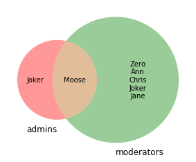

```python
# 这个 cell 集合运算图示需要安装 matplotlib 和 matplotlib-venn
# !pip install matplotlib
# !pip install matplotlib-venn
import matplotlib.pyplot as plt
from matplotlib_venn import venn2

admins = {'Moose', 'Joker', 'Joker'}
moderators = {'Ann', 'Chris', 'Jane', 'Moose', 'Zero'}

v = venn2(subsets=(admins, moderators), set_labels=('admins', 'moderators'))
v.get_label_by_id('11').set_text('\n'.join(admins & moderators))
v.get_label_by_id('10').set_text('\n'.join(admins - moderators))
v.get_label_by_id('01').set_text('\n'.join(admins ^ moderators))

plt.show()
```

以上的操作符，都有另外一个版本，即，用 Set 这个类的方法完成。

| 意义 | 操作符 | 方法 | 方法相当于 |
| --- | --- | --- | --- |
| 并集 | `\|` | `set.union(*others)` | `set \| other \| ...` |
| 交集 | `&` | `set.intersection(*others)` | `set & other & ...` |
| 差集 | `-` | `set.difference(*others)` | `set - other - ...` |
| 对称差集 | `^` | `set.symmetric_difference(other)` | `set ^ other` |

注意，并集、交集、差集的方法，可以接收多个集合作为参数 `(*other)`，但对称差集方法只接收一个参数 `(other)`。

对于集合，推荐更多使用方法而不是操作符的主要原因是：更易读 —— 对人来说，因为有意义、有用处的代码终将需要人去维护。

```python
from IPython.core.interactiveshell import InteractiveShell
InteractiveShell.ast_node_interactivity = "all"

admins = {'Moose', 'Joker', 'Joker'}
moderators = {'Chris', 'Moose', 'Jane', 'Zero'}

admins.union(moderators)
admins.intersection(moderators)
admins.difference(moderators)
admins.symmetric_difference(moderators)
```

```
{'Chris', 'Jane', 'Joker', 'Moose', 'Zero'}
```

```
{'Moose'}
```

```
{'Joker'}
```

```
{'Chris', 'Jane', 'Joker', 'Zero'}
```

### 逻辑运算

两个集合之间可以进行逻辑比较，返回布尔值。

**set** `==` **other**

> `True`: set 与 other 相同

**set** `!=` **other**

> `True`: set 与 other 不同

**isdisjoint**(*other*)

> `True`: set 与 other 非重合；即，`set & other == None`

**issubset**(*other*)，**set** `<=` **other**

> `True`: set 是 other 的子集

**set** `<` **other**

> `True`: set 是 other 的真子集，相当于 `set <= other && set != other`

**issuperset**(*other*)，**set** `>=` **other**

> `True`: set 是 other 的超集

**set** `>` **other**

> `True`: set 是 other 的真超集，相当于 `set >= other && set != other`

### 更新

对于集合，有以下更新它自身的方法：

**add**(*elem*)

> 把 elem 加入集合

**remove**(*elem*)

> 从集合中删除 elem；如果集合中不包含该 elem，会产生 KeyError 错误。

**discard**(*elem*)

> 如果该元素存在于集合中，删除它。

**pop**(*elem*)

> 从集合中删除 elem，并返回 elem 的值，针对空集合做此操作会产生 KeyEroor 错误。

**clear**() 从集合中删除所有元素。

**set.update**(**others*) ，相当于 `set |= other | ...`

> 更新 set, 加入 others 中的所有元素；

**set.intersection_update**(**others*)，相当于 `set &= other & ...`

> 更新 set, 保留同时存在于 set 和所有 others 之中的元素；

**set.difference_update**(**others*)，相当于 `set -= other | ...`

> 更新 set, 删除所有在 others 中存在的元素；

**set.symmetric_difference_update**(*other*)，相当于 `set ^= other`

> 更新 set, 只保留存在于 set 或 other 中的元素，但不保留同时存在于 set 和 other 中的元素；**注意**，该方法*只接收一个参数*。

### 冻结集合

还有一种集合，叫做冻结集合（Frozen Set），Frozen Set 之于 Set，正如 Tuple 之于 List，前者是不可变容器（Immutable），后者是可变容器（Mutable），无非是为了节省内存使用而设计的类别。

有空去看看这个链接就可以了：

> https://docs.python.org/3/library/stdtypes.html#frozenset

## 字典（Dictionary）

Map 是容器中的单独一类，**映射**（Map）容器。映射容器只有一种，叫做**字典**（Dictionary）。先看一个例子：

```python
phonebook = {'ann':6575, 'bob':8982, 'joe':2598, 'zoe':1225}
phonebook
```

```
{'ann': 6575, 'bob': 8982, 'joe': 2598, 'zoe': 1225}
```

字典里的每个元素，由两部分组成，*key*（键）和 *value*（值），二者由一个冒号连接。

比如，`'ann':6575` 这个字典元素，*key* 是 `'ann'`，*value* 是 `6575`。

字典直接使用 *key* 作为索引，并映射到与它匹配的 *value*：

```python
phonebook = {'ann':6575, 'bob':8982, 'joe':2598, 'zoe':1225}
phonebook['bob']
```

```
8982
```

在同一个字典里，*key* 都是唯一的。当创建字典的时候，如果其中有重复的 *key* 的话，就跟 Set 那样会“**自动去重**” —— 保留的是众多重复的 *key* 中的最后一个 *key:value*（或者说，最后一个 *key:value* “之前那个 *key* 的 *value* 被**更新**了”。字典这个数据类型之所以叫做 Map（映射），是因为字典里的 *key* 都映射且只映射一个对应的 *value*。

```python
phonebook = {'ann':6575, 'bob':8982, 'joe':2598, 'zoe':1225, 'ann':6585}
phonebook
```

```
{'ann': 6585, 'bob': 8982, 'joe': 2598, 'zoe': 1225}
```

在已经了解如何操作列表之后，再去理解字典的操作，其实没什么难度，无非就是字典多了几个 Methods。

提蓄一下自己的耐心，把下面的若干行代码都仔细阅读一下，猜一猜输出结果都是什么？

### 字典的生成

```python
from IPython.core.interactiveshell import InteractiveShell
InteractiveShell.ast_node_interactivity = "all"

aDict = {}
bDict = {'a':1, 'b':2, 'c':3}
aDict
bDict
```

```
{}
```

```
{'a': 1, 'b': 2, 'c': 3}
```

### 更新某个元素

```python
from IPython.core.interactiveshell import InteractiveShell
InteractiveShell.ast_node_interactivity = "all"

phonebook1 = {'ann':6575, 'bob':8982, 'joe':2598, 'zoe':1225, 'ann':6585}

phonebook1['joe']
phonebook1['joe'] = 5802
phonebook1
phonebook1['joe']
```

```
2598
```

```
{'ann': 6585, 'bob': 8982, 'joe': 5802, 'zoe': 1225}
```

```
5802
```

### 添加元素

```python
from IPython.core.interactiveshell import InteractiveShell
InteractiveShell.ast_node_interactivity = "all"

phonebook1 = {'ann':6575, 'bob':8982, 'joe':2598, 'zoe':1225, 'ann':6585}
phonebook2 = {'john':9876, 'mike':5603, 'stan':6898, 'eric':7898}

phonebook1.update(phonebook2)
phonebook1
```

```
{'ann': 6585,
 'bob': 8982,
 'joe': 2598,
 'zoe': 1225,
 'john': 9876,
 'mike': 5603,
 'stan': 6898,
 'eric': 7898}
```

### 删除某个元素

```python
from IPython.core.interactiveshell import InteractiveShell
InteractiveShell.ast_node_interactivity = "all"

phonebook1 = {'ann':6575, 'bob':8982, 'joe':2598, 'zoe':1225, 'ann':6585}

del phonebook1['ann']
phonebook1
```

```
{'bob': 8982, 'joe': 2598, 'zoe': 1225}
```

### 逻辑操作符

```python
phonebook1 = {'ann':6575, 'bob':8982, 'joe':2598, 'zoe':1225, 'ann':6585}

'ann' in phonebook1

phonebook1.keys()
'stan' in phonebook1.keys()

phonebook1.values()
1225 in phonebook1.values()

phonebook1.items()
('stan', 6898) in phonebook1.items()
```

```
True
```

```
dict_keys(['ann', 'bob', 'joe', 'zoe'])
```

```
False
```

```
dict_values([6585, 8982, 2598, 1225])
```

```
True
```

```
dict_items([('ann', 6585), ('bob', 8982), ('joe', 2598), ('zoe', 1225)])
```

```
False
```

### 可用来操作的内建函数

```python
from IPython.core.interactiveshell import InteractiveShell
InteractiveShell.ast_node_interactivity = "all"

phonebook1 = {'ann':6575, 'bob':8982, 'joe':2598, 'zoe':1225, 'ann':6585}
phonebook2 = {'john':9876, 'mike':5603, 'stan':6898, 'eric':7898}
phonebook1.update(phonebook2)

len(phonebook1)
max(phonebook1)
min(phonebook1)
list(phonebook1)
tuple(phonebook1)
set(phonebook1)
sorted(phonebook1)
sorted(phonebook1, reverse=True)
```

```
8
```

```
'zoe'
```

```
'ann'
```

```
['ann', 'bob', 'joe', 'zoe', 'john', 'mike', 'stan', 'eric']
```

```
('ann', 'bob', 'joe', 'zoe', 'john', 'mike', 'stan', 'eric')
```

```
{'ann', 'bob', 'eric', 'joe', 'john', 'mike', 'stan', 'zoe'}
```

```
['ann', 'bob', 'eric', 'joe', 'john', 'mike', 'stan', 'zoe']
```

```
['zoe', 'stan', 'mike', 'john', 'joe', 'eric', 'bob', 'ann']
```

### 常用 Methods

```python
from IPython.core.interactiveshell import InteractiveShell
InteractiveShell.ast_node_interactivity = "all"

phonebook1 = {'ann':6575, 'bob':8982, 'joe':2598, 'zoe':1225, 'ann':6585}
phonebook2 = {'john':9876, 'mike':5603, 'stan':6898, 'eric':7898}

phonebook3 = phonebook2.copy()
phonebook3

phonebook3.clear()
phonebook3

phonebook2                      # .copy() 的“原件”不会发生变化

p = phonebook1.popitem()
p
phonebook1

p = phonebook1.pop('adam', 3538)
p
phonebook1

p = phonebook1.get('adam', 3538)
p
phonebook1

p = phonebook1.setdefault('adam', 3538)
p
phonebook1
```

```
{'john': 9876, 'mike': 5603, 'stan': 6898, 'eric': 7898}
```

```
{}
```

```
{'john': 9876, 'mike': 5603, 'stan': 6898, 'eric': 7898}
```

```
('zoe', 1225)
```

```
{'ann': 6585, 'bob': 8982, 'joe': 2598}
```

```
3538
```

```
{'ann': 6585, 'bob': 8982, 'joe': 2598}
```

```
3538
```

```
{'ann': 6585, 'bob': 8982, 'joe': 2598}
```

```
3538
```

```
{'ann': 6585, 'bob': 8982, 'joe': 2598, 'adam': 3538}
```

## 迭代各种容器中元素

我们总是有这样的需求：对容器中的元素逐一进行处理（运算）。这样的时候，我们就用 `for` 循环去迭代它们。

对于迭代 `range()` 和 `list` 中的元素我们已经很习惯了：

```python
for i in range(3):
    print(i)
```

```
0
1
2
```

```python
for i in [1, 2, 3]:
    print(i)
```

```
1
2
3
```

### 迭代的同时获取索引

有时，我们想同时得到有序容器中的元素及其索引，那么可以调用 `enumerate()` 函数来帮我们：

```python
s = 'Python'
for i, c in enumerate(s):
    print(i, c)
```

```
0 P
1 y
2 t
3 h
4 o
5 n
```

```python
for i, v in enumerate(range(3)):
    print(i, v)
```

```
0 0
1 1
2 2
```

```python
L = ['ann', 'bob', 'joe', 'john', 'mike']
for i, L in enumerate(L):
    print(i, L)
```

```
0 ann
1 bob
2 joe
3 john
4 mike
```

```python
t = ('ann', 'bob', 'joe', 'john', 'mike')
for i, t in enumerate(t):
    print(i, t)
```

```
0 ann
1 bob
2 joe
3 john
4 mike
```

### 迭代前排序

可以用 `sorted()` 和 `reversed()` 在迭代前先排好序：

```python
t = ('bob', 'ann', 'john', 'mike', 'joe')
for i, t in enumerate(sorted(t)):
    print(i, t)
```

```
0 ann
1 bob
2 joe
3 john
4 mike
```

```python
t = ('bob', 'ann', 'john', 'mike', 'joe')
for i, t in enumerate(sorted(t, reverse=True)):
    print(i, t)
```

```
0 mike
1 john
2 joe
3 bob
4 ann
```

```python
t = ('bob', 'ann', 'john', 'mike', 'joe')
for i, t in enumerate(reversed(t)):
    print(i, t)
```

```
0 joe
1 mike
2 john
3 ann
4 bob
```

### 同时迭代多个容器

可以在 `zip()` 这个函数的帮助下，同时迭代两个或者两个以上的容器中的元素（这样做的前提是，多个容器中的元素数量最好相同）：

```python
chars='abcdefghijklmnopqrstuvwxyz'
nums=range(1, 27)
for c, n in zip(chars, nums):
    print(f"Let's assume {c} represents {n}.")
```

```
Let's assume a represents 1.
Let's assume b represents 2.
Let's assume c represents 3.
Let's assume d represents 4.
Let's assume e represents 5.
Let's assume f represents 6.
Let's assume g represents 7.
Let's assume h represents 8.
Let's assume i represents 9.
Let's assume j represents 10.
Let's assume k represents 11.
Let's assume l represents 12.
Let's assume m represents 13.
Let's assume n represents 14.
Let's assume o represents 15.
Let's assume p represents 16.
Let's assume q represents 17.
Let's assume r represents 18.
Let's assume s represents 19.
Let's assume t represents 20.
Let's assume u represents 21.
Let's assume v represents 22.
Let's assume w represents 23.
Let's assume x represents 24.
Let's assume y represents 25.
Let's assume z represents 26.
```

### 迭代字典中的元素

```python
phonebook1 = {'ann':6575, 'bob':8982, 'joe':2598, 'zoe':1225, 'ann':6585}

for key in phonebook1:
    print(key, phonebook1[key])
```

```
ann 6585
bob 8982
joe 2598
zoe 1225
```

```python
phonebook1 = {'ann':6575, 'bob':8982, 'joe':2598, 'zoe':1225, 'ann':6585}

for key, value in phonebook1.items():
    print(key, value)
```

```
ann 6585
bob 8982
joe 2598
zoe 1225
```

## 总结

这一章的内容，只不过是“多”而已，一旦逻辑关系理顺，就会觉得很简单。而这一章的开头，已经是最好的总结了。

最后需要补充的，只是两个参考链接，以后有什么搞不明白的地方，去那里翻翻就能找到答案：

> - https://docs.python.org/3/tutorial/datastructures.html#dictionaries
> - https://docs.python.org/3/library/stdtypes.html#typesmapping

# 文件

我们需要处理的数据，一定是很多，所以才必须由计算机帮我们处理 —— 大量的数据保存、读取、写入，需要的就是文件（Files）。在这一章里，我们只介绍最简单的文本文件。

## 创建文件

创建一个文件，最简单的方法就是用 Python 的内建函数 `open()` 。

`open()` 函数的[官方文档](https://docs.python.org/3/library/functions.html#open)很长，以下是个简化版：

> `open(file, mode='r')`

第二个参数，`mode`，默认值是 `'r'`，可用的 `mode` 有以下几种：

| 参数字符 | 意义 |
| --- | --- |
| `'r'` | 只读模式 |
| `'w'` | 写入模式（重建） |
| `'x'` | 排他模式 —— 如果文件已存在则打开失败 |
| `'a'` | 追加模式 —— 在已有文件末尾追加 |
| `'b'` | 二进制文件模式 |
| `'t'` | 文本文件模式 (默认) |
| `'+'` | 读写模式（更新） |

创建一个新文件，用这样一个语句就可以：

```python
open('test-file.txt', 'w')
```

```
<_io.TextIOWrapper name='test-file.txt' mode='w' encoding='UTF-8'>
```

当然，更多的时候，我们会把这个函数的返回值，一个所谓的 [file object](https://docs.python.org/3/glossary.html#term-file-object)，保存到一个变量中，以便后面调用这个 file object 的各种方法，比如获取文件名 `file.name`，比如关闭文件 `file.close()`：

```python
f = open('test-file.txt', 'w')
print(f.name)
f.close()
```

```
test-file.txt
```

## 删除文件

删除文件，就得调用 `os` 模块了。删除文件之前，要先确认文件是否存在，否则删除命令会失败。

```python
import os

f = open('test-file.txt', 'w')
print(f.name)

if os.path.exists(f.name):
    os.remove(f.name)
    print(f'{f.name} deleted.')
else:
    print(f'{f.name} does not exist')
```

```
test-file.txt
test-file.txt deleted.
```

## 读写文件

创建文件之后，我们可以用 `f.write()` 方法把数据写入文件，也可以用 `f.read()` 方法读取文件。

```python
f = open('test-file.txt', 'w')
f.write('first line\nsecond line\nthird line\n')
f.close()

f = open('test-file.txt', 'r')
s = f.read()
print(s)
f.close()
```

```
first line
second line
third line
```

文件有很多行的时候，我们可以用 `file.readline()` 操作，这个方法每次调用，都会返回文件中的新一行。

```python
f = open('test-file.txt', 'w')
f.write('first line\nsecond line\nthird line\n')
f.close()

f = open('test-file.txt', 'r')
s = f.readline()    # 返回的是 'first line\n'
print(s)
s = f.readline()    # 返回的是 'second line\n'
print(s)
f.close()
```

```
first line

second line
```

**注意**，返回结果好像跟你想的不太一样。这时候，之前见过的 `str.strip()` 就派上用场了：

```python
f = open('test-file.txt', 'w')
f.write('first line\nsecond line\nthird line\n')
f.close()

f = open('test-file.txt', 'r')
s = f.readline().strip()    # 返回的是 'first line'，'\n' 被去掉了……
print(s)
s = f.readline().strip()    # 返回的是 'second line'，'\n' 被去掉了……
print(s)
f.close()
```

```
first line
second line
```

与之相对的，

```python
f = open('test-file.txt', 'w')
f.write('first line\nsecond line\nthird line\n')
f.close()

f = open('test-file.txt', 'r')
s = f.readlines()    # 返回的是一个列表，注意，readlines，最后的 's'
print(s)
f.close()
```

```
['first line\n', 'second line\n', 'third line\n']
```

既然返回的是列表，那么就可以被迭代，逐一访问每一行：

```python
f = open('test-file.txt', 'w')
f.write('first line\nsecond line\nthird line\n')
f.close()

f = open('test-file.txt', 'r')
for line in f.readlines():
    print(line)
f.close()
```

```
first line

second line

third line
```

与之相对的，我们也可以用 `file.writelines()` 把一个列表写入到一个文件中，按顺序每一行写入列表的对应元素：

```python
a_list = ['first line\n', 'second line\n', 'third line\n']
f = open('test-file.txt', 'w')
f.writelines(a_list)
f.close()

f = open('test-file.txt', 'r')
for line in f.readlines():
    print(line)
f.close()
```

```
first line

second line

third line
```

## with 语句块

针对文件操作，Python 有个另外的语句块写法，更便于阅读：

```
with open(...) as f:
    f.write(...)
    ...
```

这样，就可以把针对当前以特定模式打开的某个文件的各种操作都写入同一个语句块了：

```python
import os

with open('test-file.txt', 'w') as f:
    f.write('first line\nsecond line\nthird line\n')

with open('test-file.txt', 'r') as f:
    for line in f.readlines():
        print(line)

if os.path.exists(f.name):
    os.remove(f.name)
    print(f'{f.name} deleted.')
else:
    print(f'{f.name} does not exist')
```

```
first line

second line

third line

test-file.txt deleted.
```

另外，用 `with` 语句块的另外一个附加好处就是不用写 `file.close()` 了……

## 另一个完整的程序

若干年前，我在写某本书的时候，需要一个例子 —— 用来说明“**即便是结论正确，论证过程乱七八糟也不行！**”

作者就是这样，主要任务之一就是给论点找例子找论据。找得到不仅_恰当_且又_精彩_的例子和论据的，就是好作者。后面这个“*精彩*”二字要耗费很多时间精力，因为它意味着说“要找到_很多_例子而后在里面选出_最精彩_的那个！” —— 根本不像很多人以为的那样，是所谓的“信手拈来”。

找了很多例子都不满意…… 终于有一天，我看到这么个说法：

> 如果把字母 `a` 计为 `1`、`b` 计为 `2`、`c` 计为 `3` …… `z` 计为 `26`，那么：
> - knowledge = 96
> - hardwork = 98
> - attitude = 100

> 所以结论是：
> - 知识（*knowledge*）与勤奋（*hardwork*）固然都很重要；
> - 但是，决定成败的却是态度（**attitude**）！

结论虽然有道理 —— 可这论证过程实在是太过分了罢……

我很高兴，觉得这就是个*好例子*！并且，加工一下，会让读者觉得很精彩 —— 如果能找到一些按照同样的计算方法能得到 100 的单词，并且还是那种一看就是“反例”的单词……

凭直觉，英文单词几十万，如此这般等于 100 的单词岂不是数不胜数？并且，一定会有很多负面意义的单词如此计算也等于 100 罢？然而，这种事情凭直觉是不够的，手工计算又会被累死…… 于是，面对如此荒谬的论证过程，我们竟然“无话可说”。

幸亏我是会写程序的人。所以，不会“干着急没办法”，我有能力让计算机帮我把活干了。

很快就搞定了，找到很多很多个如此计算加起来等于 100 的英文单词，其中包括：

> - connivance（纵容）
> - coyness（羞怯）
> - flurry (慌张)
> - impotence（阳痿）
> - stress（压力）
> - tuppence（微不足道的东西）
> - ……

所以，决定成败的可以是“慌张”（flurry），甚至是“阳痿”（impotence）？这不明显是胡说八道嘛！

—— 精彩例子制作完毕，我把它放进了书里。

那，具体的过程是什么样的呢？

首先我得找到一个英文单词列表，很全的那种。这事儿用不着写程序，Google 一下就可以了。我搜索的关键字是“[english word list](https://www.google.com/search?q=english+word+list)”，很直观吧？然后就找到一个：https://github.com/dwyl/english-words；这个链接里有一个 [words-alpha.txt](https://raw.githubusercontent.com/dwyl/english-words/master/words_alpha.txt) 文件，其中包含接近 37,0101 个单词，应该够用了！下载下来用程序处理就可以了！

因为文件里每行一个单词，所以，就让程序打开文件，将文件读入一个列表，而后迭代这个列表，逐一计算那个单词每个字母所代表的数字，并加起来看看是否等于 100？如果是，就将它们输出到屏幕…… 好像不是很难。

```python
with open('words_alpha.txt', 'r') as file:
    for word in file.readlines():
        pass # 先用 pass 占个位，一会儿再写计算过程
```

按照上面那说法，把 `a` 记为 `1`，直至把 `z` 记为 `26`，这事儿并不难，因为有 `ord()` 函数啊 —— 这个函数返回字符的 Unicode 编码：`ord('a')` 的值是 `97`，那按上面的说法，用 `ord('a') - 96` 就相当于得到了 `1` 这个数值…… 而 `ord('z') - 96` 就会得到 `26` 这个数值。

```python
ord('a')
```

```
97
```

那么，计算 `'knowledge'`这个字符串的代码很简单：

```python
word = 'knowledge'
sum = 0
for char in word:
    sum += ord(char) - 96
print(sum)
```

```
96
```

果然，得到的数值等于 `96` —— 不错。把它写成一个函数罢：`sum_of_word(word)`:

```python
def sum_of_word(word):
    sum = 0
    for char in word:
        sum += ord(char) - 96
    return sum

sum_of_word('attitude')
```

```
100
```

那让程序就算把几十万行都算一遍也好像很简单了：

```python
def sum_of_word(word):
    sum = 0
    for char in word:
        sum += ord(char) - 96
    return sum

with open('words_alpha.txt', 'r') as file:
    for word in file.readlines():
        if sum_of_word(word) == 100:
            print(word)
```

```
abstrusenesses

acupuncturist

adenochondrosarcoma

adenomyxosarcoma

adscititiously

adsorptiveness

anaglyptography

anesthetization

anisophyllous

annihilationistic

anomophyllous

anthropopathite

anthropophaginian

antiagglutinating

antianaphylactogen

antibacteriolytic

antichristianism

anticyclolysis

anticytolysin

anticommutative

```

[output cut: 1288 more lines]

```
virtuosities

viscometrically

vitreousness

whitlowwort

wondrousness

worshipability

zeuctocoelomatic

zygapophysis
```

嗯？怎么输出结果跟想得不一样？找到的词怎么都“奇形怪状”的…… 而且，输出结果中也没有 `attitude` 这个词。

插入个中止语句，`break`，把找到的第一个词中的每个字符和它所对应的值都拿出来看看？

```python
def sum_of_word(word):
    sum = 0
    for char in word:
        sum += ord(char) - 96
    return sum

with open('words_alpha.txt', 'r') as file:
    for word in file.readlines():
        if sum_of_word(word) == 100:
            print(word)
            for c in word:        # 把字母和值都打出来，看看对不对？
                print(c, ord(c) - 96)
            break                 # 找到一个之后就停下来。
```

```
abstrusenesses

a 1
b 2
s 19
t 20
r 18
u 21
s 19
e 5
n 14
e 5
s 19
s 19
e 5
s 19

 -86
```

怎么有个 `-86`？！仔细看看输出结果，看到每一行之间都被插入了一个空行，想到应该是从文件里读出的行中，包含'\n'这种换行符…… 如果是那样的话，那么 `ord('\n') -96` 返回的结果是 `-86` 呢，怪不得找到的词都“奇形怪状”的……

```python
ord('\n') -96
```

```
-86
```

改进一下呗 —— 倒也简单，在计算前把读入字符串前后的空白字符都给删掉就好了，用 `str.strip()` 就可以了：

```python
def sum_of_word(word):
    sum = 0
    for char in word:
        sum += ord(char) - 96
    return sum

with open('words_alpha.txt', 'r') as file:
    for word in file.readlines():
        if sum_of_word(word.strip()) == 100:
            print(word)
```

```
abactinally

abatements

abbreviatable

abettors

abomasusi

abreption

abrogative

absconders

absinthol

absorbancy

acceptavit

acceptors

acclimation

accounter

accumulate

acenaphthene

achronism

achroous

acylation

acknowledge

```

[output cut: 7486 more lines]

```
zaratite

zesting

zeuxian

zincifies

zinkify

zithern

zoogleas

zorgite
```

如果想把符合条件的词保存到一个文件 `result.txt` 里的话，那么：

```python
def sum_of_word(word):
    sum = 0
    for char in word:
        sum += ord(char) - 96
    return sum

with open('results.txt', 'w') as result:
    with open('words_alpha.txt', 'r') as file:
        for word in file.readlines():
            if sum_of_word(word.strip()) == 100:
                result.write(word)
```

竟然这么简单就搞定了？！

这 12 行的代码，在几秒钟内从接近 370,101 个英文单词中找到 3,771 个如此计算等于 100 的词汇。

喝着咖啡翻一翻 `result.txt`，很快就找到了那些可以用来做反例格外恰当的词汇。

真无法想象当年的自己若是不懂编程的话现在会是什么样子……

## 总结

这一章我们介绍了文本文件的基本操作：

> - 打开文件，直接用内建函数，`open()`，基本模式有 `r` 和 `w`；
> - 删除文件，得调用 `os` 模块，使用 `os.remove()`，删除文件前最好确认文件确实存在……
> - 读写文件分别有 `file.read()`、`file.write()`、`file.readline()`、`file.readlines()`、`file.writelines()`；
> - 可以用 `with` 把相关操作都放入同一个语句块……

# 如何从容应对含有过多“过早引用”的知识？

“过早引用”（[Forward References](https://en.wikipedia.org/wiki/Forward_declaration#id=Forward_reference)，另译为“前置引用”），原本是计算机领域的术语。

在几乎所有的编程语言中，对于变量的使用，都有“先声明再使用”的要求。直接使用未声明的变量是被禁止的。Python 中，同样如此。如果在从未给 `an_undefined_variable` 赋值的情况下，直接调用这个变量，比如，`print(an_undefined_variable)`，那就会报错：`NameError: name 'an_undefined_variable' is not defined`。

```python
print(an_undefined_variable)
```

```
---------------------------------------------------------------------------
NameError                                 Traceback (most recent call last)
<ipython-input-1-7e0e1cc14e37> in <module>
----> 1 print(an_undefined_variable)

NameError: name 'an_undefined_variable' is not defined
```

充满过早引用的知识结构，在大脑中会构成类似 M.C. Escher 善画的那种“不可能图形”那样的“结构”。

[figure not shown]

在上图中，前三个椎形一般不会造成视觉困惑 —— 尤其是第一个。

若是加上虚线，比如，第二个和第三个，那么由于我们预设虚线表示“原本应该看不见的部分”，于是，`C` 点的位置相对于 `B` 和 `D` 应该更靠近自己；`C'` 的位置，相对于 `B'` 和 `D'` 应该更远离自己……

然而，在第四个椎形中，由于 `B"D"` 和 `A"C"` 都是实线，于是，我们一下子就失去了判断依据，不知道 `C"` 究竟是离自己更近还是更远？

对一个点的位置困惑，连带着它与其它三个点之间的关系。可若那不是锥体，而是立方体呢？每个点的位置困惑会造成对它与更多点之间的更多联系的困惑…… 若是更多面体呢？

[figure not shown]

把这些令人困惑的点，比喻成“过早引用”，你就明白为什么“很多过早引用”的知识结构会那么令人困惑，处理起来那么令人疲惫了吧？

## 过早引用就是无所不在

可生活、学习、工作，都不是计算机，它们可不管这套，管它是否定义过，管它是否定义清晰，直接甩出来就用的情况比比皆是。

对绝大多数“不懂事”的小朋友来说，几乎所有痛苦的根源都来自这里：“懂事”的定义究竟是怎样的呢？什么样算作懂事，什么样算作不懂事？弄不好，即便整个童年都在揣摩这个事儿，到最后还是迷迷糊糊。他们的父母，从未想过对孩子说话也好提要求也好，最好“先声明再使用”，或者即便事先声明过也语焉不详…… 于是，这些可怜的孩子，能做的只有在惶恐中摸索，就好像在黑暗中拼图一样。

可事实上，他们的父母也不容易。因为确实有太多细节，给小朋友讲了也没用，或者讲也讲不清楚，又或者拼命解释清楚了，但小朋友就是听不进去…… 所以，令人恼火的“过早引用”，有时候真的是只能那样的存在。

谈恋爱的时候也是这样。太多的概念，千真万确地属于过早引用。爱情这东西究竟是什么，刚开始的时候谁都弄不大明白。并且事实证明，身边的绝大多数人跟自己一样迷糊。至于从小说电影里获得的“知识”，虽然自己看心神愉悦，但几乎肯定给对方带来无穷无尽的烦恼 —— 于对方来说你撒出来的是漫天飞舞的过早引用……

到了工作阶段，技术岗位还相对好一点，其他领域，哪哪儿都是过早引用，并且还隐藏着不可见，搞得人们都弄出了一门玄学，叫做“潜规则”。

人们岁数越大，交朋友越来越不容易。最简单的解释就是，每个人的历史，对他人来说都构成“过早引用”。所以，理解万岁？太难了吧，幼儿园、小学的时候，人们之间几乎不需要刻意相互理解，都没觉得有这个必要；中学的时候，相互理解就已经开始出现不同程度的困难了，因为过早引用的积累。大学毕业之后，再工作上几年，不仅相互理解变得越来越困难，还有另外一层更大的压力 —— 生活中要处理的事情越来越多，脑力消耗越来越大，遇到莫名其妙的过早引用，哪儿有心思处理？

## 不懂也要硬着头皮读完

这是事实：大多数难以掌握的技能都有这个特点。人们通常用“学习曲线陡峭”来形容这类知识，只不过，这种形容只限于形容而已，对学习没有实际的帮助。面对这样的实际情况，有没有一套有效的应对策略呢？

首先是要学会一个重要的技能：

> **读不懂也要读完，然后重复很多遍。**

这是最重要的起点。听起来简单，甚至有点莫名其妙 —— 但，以后你就会越来越深刻地体会到，这么简单的策略，竟然是绝大多数人并不懂的，也因此吃了很多很多亏。

充满了过早引用的知识讲解，就不可能是一遍就读懂的。别说这种信息密度极高的复杂且重要的知识获取了，哪怕你去看一部好电影，也要多刷几遍才能彻底看懂，不是嘛？比如，Quentin Tarantino 导演的 [Pulp Fiction (1994)](https://www.imdb.com/title/tt0110912/)、David Fincher 导演的 [Fight Club (1999)](https://www.imdb.com/title/tt0137523/) 、Christopher Nolan 导演的 [Inception (2010)](https://www.imdb.com/title/tt1375666/)、或者 Martin Scorsese 导演的 [Shutter Island (2010)](https://www.imdb.com/title/tt1130884/)……

所以，从一开始就要做好_将要重复很多遍_的准备，从一开始就要做好_第一次只能读懂个大概_的准备。

古人说，读书百遍其义自见，道理就在这里了 —— 只不过，他们那时候没有计算机术语可以借用，所以，这道理本身成了“过早引用”，对那些根本就没有过“读书百遍”经历的人，绝对以为那只不过是在忽悠自己……

有经验的读书者，拿来一本书开始自学技能的时候，他会先翻翻目录（Table Of Contents），看看其中有没有自己完全没有接触过的概念；然后再翻翻术语表（Glossary），看看是否可以尽量理解；而后会看看索引（Index），根据页码提示，直接翻到相关页面进一步查找…… 在通读书籍之前，还会看看书后的参考文献（References），看看此书都引用了哪些大牛的书籍，弄不好会顺手多买几本。

这样做，显然是老到 —— 这么做的最大好处是“尽力消解了大量的过早引用”，为自己减少了极大的理解负担。

所以，第一遍的正经手段是“**囫囵吞枣**地读完”。

囫囵吞枣从一开始就是贬义词。但在当前这个特殊的情况下，它是最好的策略。那些只习惯于一上来就仔细认真的人，在这里很吃亏，因为他们越是仔细认真，越是容易被各种过早引用搞得灰心丧气；相应地，他们的挫败感积累得越快；到最后弄不好最先放弃的是他们 —— 失败的原因竟然是因为“太仔细了”……

第一遍囫囵吞枣，用个正面一点的描述，就是“*为探索未知领域先画个潦草的地图*”。地图这东西，有总比没有好；虽然说它最好精确，但，即便是“不精确的地图”也比“完全没地图”好一万倍，对吧？更何况，这地图总是可以不断校正的，不是吗？世界上哪个地图不是一点一点校正过来才变成今天这般精确的呢？

## 磨练“只字不差”的能力

通过阅读习得新技能（尤其是“尽量只通过阅读习得新技能”），肯定与“通过阅读获得心灵愉悦”很不相同。

读个段子、读个小说，读个当前热搜文章，通常情况下不需要“精读” —— 草草浏览已经足够，顶多对自己特别感兴趣的地方，慢下来仔细看看……

但是，若是为了习得新技能去阅读，就要施展“**只字不差地阅读**”这项专门的技能。

对，“只字不差地阅读”是所有自学能力强的人都会且都经常使用的技能。尤其是当你在阅读一个重要概念的定义之时，你就是这么干的：定义中的每个字都是有用的，每个词的内涵外延都是需要进行推敲的，它是什么，它不是什么，它的内涵外延都是什么，因此，在使用的时候需要注意什么……

很有趣的一个现象是，绝大多数自学能力差的人，都是把一切都当作小说去看，随便看看，粗略看看……

你有没有注意到一个现象，人们在看电影的时候，绝大多数人会错过绝大多数细节；但，这好像并不会削减他们的观影体验；并且，他们有能力使用错过了无数细节之后剩下的那些碎片拼接出一个“完整的故事” —— 当然，通常干脆是“另一个貌似完整的故事”。于是，当你在跟他们讨论同一个电影的时候，常常像是你们没坐在同一个电影院，看的不是同一个电影似的……

所谓的自学能力差，很可能最重要的坑就在这里：

> 每一次学习新技能的时候，很多人只不过是因为做不到只字不差地阅读，于是总是会错过很多细节；于是，最终就好像“看了另外一个山寨版电影一样”，实际上“习得了另外一个山寨版技能”……

在学习 Python 语言的过程中，有个例子可以说明以上的现象。

在 Python 语言中，`for` 循环可以附加一个 `else` 部分。你到 Google 上搜索一下 [`for else python`](https://www.google.com/search?q=for+else+python) 就能看到有多少人在“追问”这是干什么的？还有另外一些链接，会告诉你“for... else”这个“秘密”的含义，将其称为“语法糖”什么的……

其实，[官方教程](https://docs.python.org/3/tutorial/controlflow.html#break-and-continue-statements-and-else-clauses-on-loops)里写的非常清楚的，并且还给出了一个例子：

> Loop statements may have an else clause; it is executed when the loop terminates through exhaustion of the list (with for) or when the condition becomes false (with while), but not when the loop is terminated by a break statement. This is exemplified by the following loop, which searches for prime numbers:

> ```
> >>> for n in range(2, 10):
> ...     for x in range(2, n):
> ...         if n % x == 0:
> ...             print(n, 'equals', x, '*', n//x)
> ...             break
> ...     else:
> ...         # loop fell through without finding a factor
> ...         print(n, 'is a prime number')
> ...
> 2 is a prime number
> 3 is a prime number
> 4 equals 2 * 2
> 5 is a prime number
> 6 equals 2 * 3
> 7 is a prime number
> 8 equals 2 * 4
> 9 equals 3 * 3
> ```

只有两种情况，

> - 要么干脆就没读过，
> - 要么是读了，却没读到这个细节……

—— 后者更为可怕，跟花了同样的钱看了另外一个残缺版本的电影似的……

为什么说“只字不差地阅读”是一项专门的技能呢？你自己试过就知道了。明明你已经刻意让自己慢下来，也刻意揣摩每个字每个词的含义，甚至为了理解正确，做了很多笔记…… 可是，当你再一次“只字不差地阅读”的时候，你经常会“惊讶地发现”，自己竟然有若干处遗漏的地方！对，这就是一种需要多次练习、长期训练才能真正掌握的技能。绝对不像听起来那么简单。

所以，*到了第二遍第三遍就必须施展“只字不差地阅读”这项专门的技能了*，只此一点，你就已然**与众不同**了。

## 好的记忆力很重要

“就算读不懂也要读完”的更高境界，是“**就算不明白也要先记住**”。

人们普遍讨厌“死记硬背”…… 不过，说实话，这很肤浅。虽然确实也有“擅长死记硬背却就是什么都不会的人”，但是，其实有更多记忆力强的人，实际上更可能是“博闻强识”。

面对“过早引用”常见的知识领域，好记忆力是超强加分项。记不清、记不住、甚至干脆忘了 —— 这是自学过程中最耽误事儿的缺点。尤其在有“过早引用知识点”存在的时候，更是如此。

然而，很多人并没有意识到的是，记忆力也是“一门手艺”而已。并且，事实上，它是任何时候都可以通过刻意练习加强的“手艺”。

更为重要的是，记忆力这个东西，有一百种方法去弥补 —— 比如，最明显、最简单的办法就是“好记性不如烂笔头”……

所以，在绝大多数正常情况下，所谓的“记不清、记不住、甚至干脆忘了”，都只不过是懒的结果 —— 若是一个人懒，且不肯承认自己懒，又因为不肯承认而已就不去纠正，那…… 那就算了，那就那么活下去罢。

然而，提高对有效知识的记忆力还有另外一个简单实用的方法 —— 而市面上有各种“快速记忆法”，通常相对于这个方法来看用处并不大。

这个方法就是以下要讲到的“整理归纳总结” —— **反复做整理归纳总结，记不住才怪呢！**

## 尽快开始整理归纳总结

从另外一个角度，这类体系的知识书籍，对作者来说，不仅是挑战，还是摆脱不了的负担。

Python 官方网站上的 [The Python Tutorial](https://docs.python.org/3/tutorial/index.html)，是公认的最好的 Python 教材 —— 因为那是 Python 语言的作者 [Guido van Rossum](https://en.wikipedia.org/wiki/Guido_van_Rossum) 写的……

虽然 Guido van Rossum 已经很小心了，但还是没办法在讲解上避免大量的过早引用。他的小心体现在，在目录里就出现过五次 **More**：

> - More Control Flow Tools
> - More on Defining Functions
> - More on Lists
> - More on Conditions
> - More on Modules

好几次，他都是先粗略讲过，而后在另外一处再重新深入一遍…… 这显然是一个最尽力的作者了 —— 无论是在创造一个编程语言上，还是在写一本教程上。

然而，即便如此，这本书对任何初学者来说，都很难。当个好作者不容易。

于是，这只能是读者自己的工作了 —— 因为即便是最牛的作者，也只能到这一步了。

第一遍囫囵吞枣之后，马上就要开始“**总结**、**归纳**、**整理**、**组织** 关键知识点”的工作。自己动手完成这些工作，是所谓学霸的特点。他们只不过是掌握了这样一个其他人从未想过必须掌握的简单技巧。他们一定有个本子，里面是各种*列表*、*示意图*、*表格* —— 这些都是最常用的知识（概念）整理组织归纳工具，这些工具的用法看起来简单的要死。

这个技巧说出来、看起来都非常简单。然而，也许正因为它看起来如此简单，才被绝大多数人忽略…… 与学霸们相对，绝大多数非学霸都有一模一样的糊弄自己的理由：反正有别人做好的，拿过来用就是了！—— 听起来那么理直气壮……

可实际上，**自己动手做做就知道了** —— 整理、归纳、组织，再次反复，是个相当麻烦的过程。非学霸们自己不动手做的真正原因只不过是：嫌麻烦、怕麻烦。一个字总结，就是，**懒**！可是，谁愿意承认自己懒呢？没有人愿意。于是，都给自己找个冠冕堂皇的理由，比如，上面说的“反正别人已经做好了，我为什么还要再做一遍呢？” 再比如，“这世界就是懒人推进的！”

久而久之，各种爱面子的说法完美地达成了自我欺骗的效果，最后连自己都信了！于是，身上多了一个明明存在却永远找不到的漏洞 —— **且不自知**。

我在第一次粗略读过整个 [Python Official Tutorial](https://docs.python.org/3/tutorial/datastructures.html) 中的第五章之后，顺手整理了一下 Containers 的概念表格：

[figure not shown]

**可这张图错了！**

于是肯定需要再次整理，若干次改进之后，那张图就变成了下面这个样子：

[figure not shown]

> 另外，从 Python 3.7 开始，Dictionary 是 insertion ordered 了：  
> https://docs.python.org/3/library/collections.html#ordereddict-objects

这个自己动手的过程其实真的“很麻烦”，但，它实际上是帮助自己强化记忆的过程，并且对自我记忆强化来说，绝对是不可或缺的过程。习惯于自己动手做罢！习惯于自己不断修改罢！

再给你看个善于学习的人的例子：

> https://nvie.com/posts/iterators-vs-generators/

作者 Vincent Driessen 在这个帖子里写到：

> I'm writing this post as a pocket reference for later.

人家随手做个图，都舍不得不精致：

[figure not shown]

自学能力强的人有个特点，就是**不怕麻烦**。小时候经常听到母亲念叨，“怕麻烦！那还活着干嘛啊？活着多麻烦啊！” —— 深刻。

## 先关注使用再研究原理

作为人类，我们原本很擅长运用自己并不真正理解的物件、技能、原理、知识的……

三千多年以前，一艘欧洲腓尼基人的商船在贝鲁斯河上航行的时候搁浅了…… 于是，船员们纷纷登上沙滩。饿了怎么办？架火做饭呗。吃完饭，船员们惊讶地发现锅下面的沙地上有很多亮晶晶、闪闪发光的东西！今天的化学知识对当年的他们来说，是那一生不可触摸的“过早引用”。他们并不懂这个东西的本质、原理，但，稍加研究，他们发现的是，锅底沾有他们运输的天然苏打…… 于是，他们的总结是，天然苏打和沙子（我们现在知道沙子中含有石英砂）被火烧，可能会产生这个东西。几经实验，成功了。于是，腓尼基人学会了制做玻璃球，发了大财……

两千五六百年之前，释加牟尼用他的理解以及在那个时代有限的概念详细叙述了打坐的感受 —— 他曾连续打坐 6 年。今天，西方科学家们在深入研究脑科学的时候，发现 Meditation 对大脑有特别多的好处…… 这些好处就是好处，与宗教全然没有任何关系的好处。

> - [Harvard neuroscientist: Meditation not only reduces stress, here’s how it changes your brain](https://www.washingtonpost.com/news/inspired-life/wp/2015/05/26/harvard-neuroscientist-meditation-not-only-reduces-stress-it-literally-changes-your-brain/)
> - [This Is Your Brain on Meditation -- The science explaining why you should meditate every day](https://www.psychologytoday.com/us/blog/use-your-mind-change-your-brain/201305/is-your-brain-meditation)
> - [Researchers study how it seems to change the brain in depressed patients](https://news.harvard.edu/gazette/story/2018/04/harvard-researchers-study-how-mindfulness-may-change-the-brain-in-depressed-patients/)
> - [Meditation’s Calming Effects Pinpointed in the Brain](https://www.scientificamerican.com/article/meditations-calming-effects-pinpointed-in-brain/)
> - [Different meditation types train distinct parts of your brain](https://www.newscientist.com/article/2149489-different-meditation-types-train-distinct-parts-of-your-brain/)

你看，我们原本就是可以直接使用自己并不真正理解的物件、技能、原理、知识的！可为什么后来就不行了呢？

或者说，从什么时候开始，我们开始害怕自己并不真正理解的东西，不敢去用，甚至连试都不敢去试了呢？

有一个相当恼人的解释：**上学上坏了**。

学校里教的全都是属于“先声明再使用”的知识。反过来，不属于这种体系架构的知识，学校总是回避的 —— 比如，关于投资与交易的课程，从来看不见地球上有哪个义务教育体系把它纳入教学范围。虽然，投资与交易，是每个人都应该掌握、都必须掌握的不可或缺的技能，某种意义上它甚至比数学语文都更重要，然而，学校就是不会真教这样的东西。

而且，现在的人上学的时间越来越长。小学、初中、高中、本科加起来 16 年…… 这么长时间的“熏陶”，只能给大多数人造成幻觉，严重、深刻，甚至不可磨灭的幻觉，误以为所有的知识都是这种类型…… 可偏偏，这世界上真正有用的、真正必要的知识，几乎全都不是这种类型 —— 颇令人恼火。

现在的你，不一样了 —— 你要跳出来。养成一个习惯：

> 不管怎么样，先用起来，反正，研究透原理，不可能马上做到，需要时间漫漫。

用错了没关系，改正就好。用得不好没关系，用多了就会好。只要开始用起来，理解速度就会加快 —— 实践出真知，不是空话。

有的时候，就是因为没有犯过错，所以不可能有机会改正，于是，就从未做对过。

## 尊重前人的总结和建议

生活中，年轻人最常犯的错误就是把那句话当作屁：

> 不听老人言，吃亏在眼前。

对年轻人来讲，老人言确实很讨厌，尤其是与自己当下的感受相左的时候。

然而，这种“讨厌”的感觉，更多的时候是陷阱，因为那些老人言只不过是过早引用，所以，在年轻人的脑子里“无法执行”，“报错为类型错误”……

于是，很多人一不小心就把“不听老人言”和“独立思考”混淆起来，然后最终自己吃了亏。可尴尬在于，等自己意识到自己吃亏了的时候吧，大量的时间早已飘逝，是为“无力回天”。

你可以观察到一个现象，学霸（好学生）的特点之一就是“老师让干啥就干啥”，没废话。

比如，上面告诉你了，“必须自己动手”，那你就从现在开始老老实实地在一切必要的情况下自己动手去“**总结**、**归纳**、**整理**、**组织** 关键知识点”…… 那你就必然能够学好。但针对这么个建议，你反复在那里问，“为什么呀？”，“有没有更简单的办法啊？”…… 那你就完了，死定了。

学写代码的过程中，有很多重要的东西实际上并不属于“编程语言范畴”。比如，如何为变量命名、如何组织代码，这些“规范”，不是违背了就会马上死掉的<sup>[1]</sup>；并且，初来乍到的时候，这些东西看起来就是很啰嗦、很麻烦的…… 然而，这些东西若是不遵守，甚至干脆不了解，那么最终的结果是，你永远不可能写出大项目，永远是小打小闹 —— 至于为什么，可以用那句你最讨厌的话回答你：

> 等你长大了就懂了……

自学编程的好处之一，就是有机会让一个人见识到“规范”、“建议”的好处。也有机会让一个人见识到不遵守这些东西会吃怎样的亏（往往是现世报）。

Python 中有一个概念叫 PEP，Python Enhancement Proposals，必须找时间阅读，反复阅读，牢记于心：

> https://www.python.org/dev/peps/pep-0008/

到最后，你会体会到，这不只是编程的事儿，这种东西背后的思考与体量，对整个人生都有巨大帮助。

**脚注**

[1]：也可能真的会死…… 请看一篇 2018 年 9 月份的一则新闻，发生在旧金山的事情：[Developer goes rogue, shoots four colleagues at ERP code maker](https://www.theregister.co.uk/2018/09/20/developer_work_shooting/)

↑Back to Content↑

# 官方教程：The Python Tutorial

虽然，第一部分总计七章关于编程内容的编排是非常特别且相当有效的：

> - 它并没有像其它教程那样，从“Hello world!”入手；
> - 它也没有使用与市面上所有编程教材一样的内容先后顺序；
> - 它一上来就让你明白了程序的灵魂：布尔运算；
> - 它很快就让你明白有意义的程序其实只有两个核心构成：运算和流程控制；
> - 它让你很快理解函数从另外一个角度看只不过是“程序员作为用户所使用的产品”；
> - 它让你重点掌握了最初级却最重要的数据类型，字符串；
> - 它让你从容器的角度了解了 Python 中绝大多数“重要的数据类型”；
> - 最重要的是，它不承诺你“速成”，但承诺“领你入门”…… 显然，它做到了。

但是，第一部分的内容核心目标是让你“**脱盲**” —— 它的作用还做不到让你“已然学会编程”，它更多是让你从此开始有能力去阅读更多的重要资源，比如，官方的教程和参考。第一部分的内容更像地图上的“**图例**”，而不是地图本身。

第一部分反复读过之后，最重要的结果就是：

> 现在你有能力自己查询官方文档了……

起码，在此之后，再去阅读 [The Python Tutorial](https://docs.python.org/3/tutorial/index.html)，不那么费力了，最起码，可以靠自己理解绝大多数内容……

在继续阅读本书内容的同时，有空就要反复翻 The Python Tutorial。

## 官方文档中最重要的链接

Python 也许是目前所有编程语言中在文档建设（Documenting）方面做得最好的（好像真的不需要在这句话后面加上“之一”）。Python 社区为了建设完善的文档，甚至有专门的文档制作工具 —— 得益于 Python 社区从一开始就非常重视[文档规范](https://devguide.python.org/documenting/) —— [Sphinx](http://www.sphinx-doc.org/en/master/)。你在网络上最经常看到的计算机类文档，很可能都在这个网站上：[Read the Docs](https://readthedocs.org)……

Python 的官方文档网址是：

> https://docs.python.org/3/

其中对初学者最重要的两个链接是：

> - **[Tutorial](https://docs.python.org/3/tutorial/index.html)**: https://docs.python.org/3/tutorial/index.html
> - **[Library Reference](https://docs.python.org/3/library/index.html)**: https://docs.python.org/3/library/index.html

理论上来讲，只要有了基础的概念，自己反复阅读官方的 The Python Tutorial 是最好的，没什么入门书籍比它更好 —— 因为它的作者是 Python 的作者，那个被称为“善意独裁者”的 [Guido van Rossum](https://en.wikipedia.org/wiki/Guido_van_Rossum)。

此人很帅，但更帅的是他的车牌（摘自 Guido van Rossume 的[个人主页](https://gvanrossum.github.io)）：

[figure not shown]

## 为什么一定要阅读官方文档

买一两本 Python 教程是不可能完整掌握 Python 的 —— 其实，这句话里的 Python 替换成任何一种语言也是一样的。

教程和官方文档的各种属性是非常不一样的，比如，针对读者群，组织方式，语言表达…… 最不一样的地方在“全面性”。任何一本单独的教程，都不可能像官方文档那样全面。各种单独教程的优势在于，它们更多地针对初学者、入门者设计，但与此同时，在全面性、深入性上做了妥协。

比如，在当前这本书里，不会涉及 [Bytes Object](https://docs.python.org/3/library/stdtypes.html#bytes-objects) —— 并非只有我一个人这么做，著名的 Python 教程《[Think Python: How to Think Like a Computer Scientist](http://greenteapress.com/thinkpython2/html/index.html)》、《[Dive into Python](https://linux.die.net/diveintopython/html/toc/index.html)》等等都没有涉及 Bytes Object 这个话题。

由于官方文档实际上没办法对入门者、初学者过分友好 —— 毕竟，全面、权威、准确才是它更应该做到的事情 —— 所以，很多人在刚开始的时候求助于各类非官方的教材、教程。原本应该是入门以后就理应“只读官方文档”，或者“第一查询对象只能是官方文档”，但，在很多人那里竟然变成了“从一开始到最后都在回避官方文档（或者说‘最专业的说明文字’），这就不好了，真的很吃亏，且自己都无法知道自己究竟吃了多少亏 —— 总以为自己已经学完了，但实际上从一开始就一点都不全面。

请牢记且遵守这个原则：

> **第一查询对象只能是官方文档**。

所以，当我用 Google 查询的时候，经常使用这样的格式：

> `<querries> site:python.org`

有时甚至会指定在那个目录里搜索：

> `bytes site:python.org/3/library`，你试试这个连接：[bytes site:python.org/3/library](https://www.google.com/search?q=byte+site%3Apython.org%2F3%2Flibrary)

这个原则对任何语言都适用。将来你在学习任何新软件包（库）、语言更新后的新特性、甚至另外一个新语言的时候，都要这么做。所谓的超强自学能力，基本上就是由一些类似这样的小习惯和另外一些特别基础的方法构成的强大能力。

## 将官方文档拉回本地

把 The Python Tutorial 拉回本地阅读，可能更为方便，尤其是可以用 Sphinx 重新制作之后，页面左侧可以总是显示完整的目录：

[figure not shown]

也可以把这个教程转换成 epub 格式，以便在移动设备上阅读；甚至可以把这些个页面的 `.rst` 源文件转换成 `.ipynb` 文件，以便用 Jupyter Lab 浏览时可以直接执行其中的代码……

**注意**

> 此页的 Code Cell 中都是可执行的 bash 命令……

在此页执行它们对你来说是没意义的 —— 因为它们的执行结果在服务器上；这其中的命令，应该在你本地计算机上的 Terminal 中执行，你才能在本地计算机上获取结果。

### 安装 git

```python
%%bash
which git
git --version

# 没有的话就执行以下命令安装 git
# conda install -c anaconda git
```

### 下载源文件

The Python Tutorial 的源文件位置在：

> https://github.com/python/cpython/tree/master/Doc/tutorial

repo 地址是：

> https://github.com/python/cpython.git

使用 git 将 repo 下载到 `~/Download/` 目录：

```python
%%bash
cd ~/Downloads
# 总计 241 M，所以需要一点时间
git clone https://github.com/python/cpython.git
cd cpython/Doc/tutorial
ls
```

### 安装 rst2ipynb

```python
%%bash
# rst2ipynb needs pandoc and notedown...
which pandoc
which notedown
# 没有这两样东西的话，需要执行下面两行进行安装……
# conda install -c conda-forge pandoc
# conda install -c conda-forge notedown

# install rst2ipynb
cd ~/Downloads
git clone https://github.com/nthiery/rst-to-ipynb.git
cd rst-to-ipynb
pip install .
which rst2ipynb
```

### 批量转换 rst 至 ipynb

这个 rst2ipynb 的程序有点讨厌，一次只能处理一个文件…… 下面是一个 bash 程序，其实将来学起来也不难，看着跟 Python 差不多…… 下面的代码执行过后会出现很多“警告” —— 没关系，文件会正常转换的。

```python
%%bash
cd ~/Downloads/cpython/Doc/tutorial/
for f in *.rst
    do
        rst2ipynb $f -o "${f/%.rst/.ipynb}"
    done
mkdir ipynbs
mv *.ipynb ipynbs/
```

如此这般，你就把 rst 文件都转换成 ipynb 文件，保存在 `~/Downloads/cpython/Doc/tutorial/ipynbs/` 之中了。随便把它挪到你喜欢的什么地方。用本地的 Jupyterlab 浏览，或者用 [Nteract](https://nteract.io) App 浏览。

如果以后你经常需要批量转换某个目录内的 `rst` 文件，那就把 bash function 放在 `~/.bash_profile` 文件里，在最后面追加以下代码：

```
function rsti {
    for f in *.rst
    do
    rst2ipynb $f -o "${f/%.rst/.ipynb}"
    done
}
```

而后在 Terminal 里执行一遍：

```
source ~/.bash_profile
```

而后，在有 `.rst` 文件的目录下输入 `rsti` 执行即可……

### 用 Sphinx 生成 html/epub 版本

```python
%%bash
which sphinx-quickstart
# 没有的话就执行下一行：
# conda install -c anaconda sphinx
sphinx-quickstart --version
sphinx-quickstart --help
```

生成 html 版本和 epub 版本：

```python
%%bash
cd ~/Downloads/cpython/Doc/tutorial/
sphinx-quickstart -q output --sep -p 'The Python Tutorial' -a 'Guido van Rossum' -r '1.0' -v '1.0' -l 'en' --suffix '.rst' --master 'index' --ext-autodoc --ext-doctest --ext-intersphinx --ext-todo --ext-coverage --ext-imgmath --ext-mathjax --ext-ifconfig --ext-viewcode --makefile --no-batchfile --no-use-make-mode
cp -f *.rst output/source/
cd output
make html
make epub

# 生成的 html 版本应该在 output/build/html 目录下；
# 生成的 epub 版本应该在 output/build/epub 目录下。

# sphinx-quickstart -q output \
# --sep \
# -p 'The Python Tutorial' \
# -a 'Guido van Rossum' \
# -v '1.0'
# -r '1.0' \
# -l 'en' \
# --suffix '.rst' \
# --master 'index' \
# --ext-autodoc \
# --ext-doctest \
# --ext-intersphinx \
# --ext-todo \
# --ext-coverage \
# --ext-imgmath \
# --ext-mathjax \
# --ext-ifconfig \
# --ext-viewcode \
# --makefile \
# --no-batchfile \
# --no-use-make-mode
```

用 Sphinx 这样生成的版本，支持本地目录内搜索，也确实比在网站上看更方便一点：

[figure not shown]

### 下载已经转换好的版本

万一有什么情况中间出错又搞不定的话，就直接下载已经转换好的版本：

```python
%%bash
cd ~/Downloads
git clone https://github.com/xiaolai/the-python-tutorial-in-other-formats.git
```

### 完整的 Python Doc 制作

其实，Python 的整个文档，已经是做好了制作文件的文档库：

> `cpython/Doc/Makefile`

只不过，将所有文件编译到一个 epub 里，在 iPad 之类的移动设备上打开有点费劲 —— 在我的设备上显示有 7701 页，翻页都要顿一顿……

想要使用这个官方的 `Makefile` 的话，首先确认自己已经安装过 Sphinx，其次需要补充安装一个包：

```
pip install blurb
```

而后在 Terminal 中转到 Doc 所在目录，执行以下命令：

```
make html
make epub
```